# L’àmbit municipal i el vot a Vox

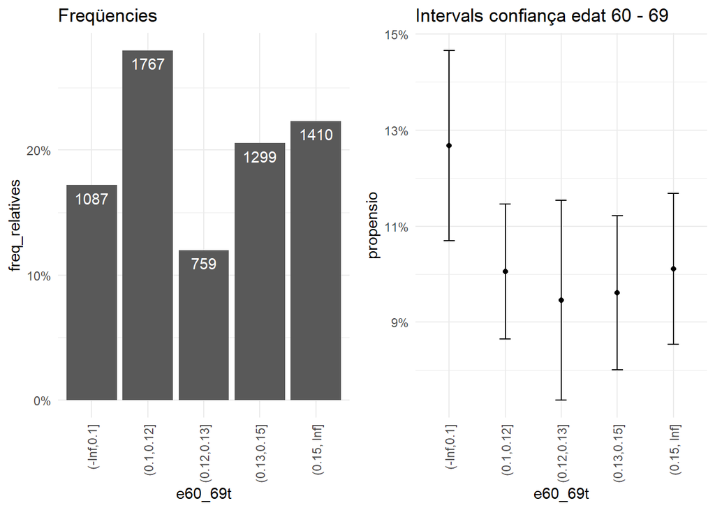

```r
p22 <- PROPEN13 %>%
  ggplot(aes(e60_69t , freq_relatives)) +
  geom_bar(stat="identity")+
  geom_text(aes(label = freq_absolutes), vjust=1.6, color="white")+
  scale_y_continuous(labels = percent)+
  theme_minimal()+
  theme(axis.text.x = element_text(angle = 90, vjust = 0.5, hjust=1))+
  labs(title="Freqüencies")

p23 <- PROPEN13 %>%
  ggplot(aes(e60_69t, propensio)) +
  geom_point(size = 1.5) +
  geom_errorbar(aes(ymin =I_minim, ymax = I_maxim, width = .2))+
  scale_y_continuous(labels = percent)+
  theme_minimal()+
  theme(axis.text.x = element_text(angle = 90, vjust = 0.5, hjust=1))+
  labs(title="Intervals confiança edat 60 - 69")

plot_grid(p22, p23, ncol=2)
```

### 2.2.2.6 Vot a Vox i edat 70 - 79

```r
cor(d2$e70_79,d2$VOX)
```

```
## [1] -0.06287652
```

```r
cor(logit(d2$e70_79),logit(d2$VOX), use = "pairwise.complete.obs")
```

```
## [1] -0.0180569
```

```r
cor(d2$e70_79,logit(d2$VOX), use = "pairwise.complete.obs")
```

```
## [1] 0.01500536
```

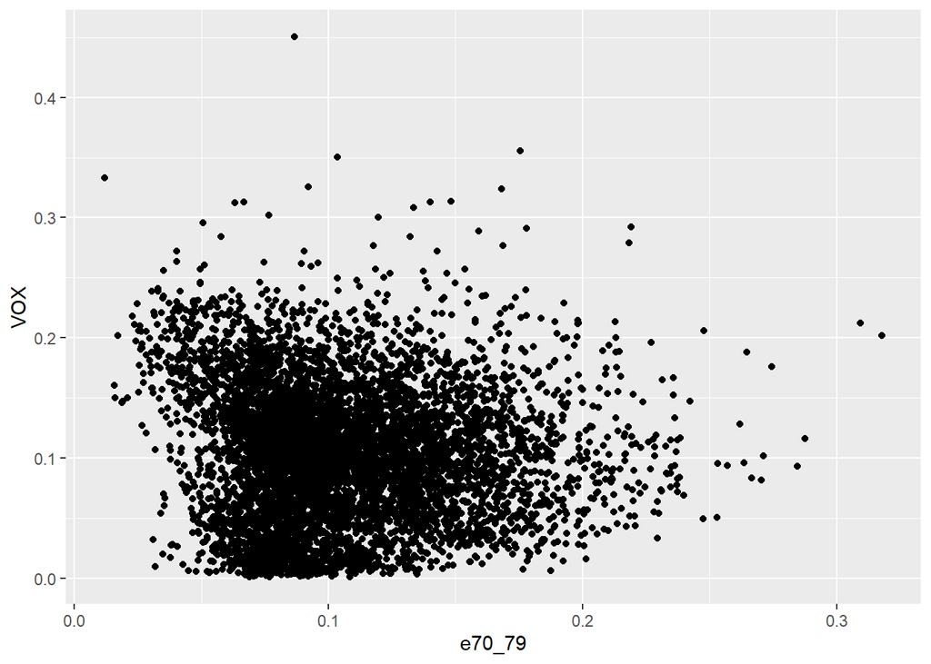

```r
d2 %>% ggplot(aes(x = e70_79, y = VOX))+
  geom_point()
```

### Propensión del vot a Vox i edat 70 - 79 anys

```r
 quantile(d2$e70_79, seq(0,1,0.2))
```

```
##         0%        20%        40%        60%        80%       100%
## 0.01182432 0.07373114 0.08966878 0.10921034 0.13737152 0.31775701
```

```r
d2 <- d2 %>%
  mutate(e70_79t = cut(e70_79, c(-Inf, 0.07, 0.09, 0.11, 0.14, Inf )))

d2 %>% count(e70_79t)
```

```
##       e70_79t    n
## 1 (-Inf,0.07]  988
## 2 (0.07,0.09] 1572
## 3 (0.09,0.11] 1263
## 4 (0.11,0.14] 1332
## 5 (0.14, Inf] 1167
```

```r
PROPEN14 <- d2 %>%
  group_by(e70_79t) %>%
  summarise(freq_absolutes = n()
    ,I_minim = minInt_bin(VOX )
         ,propensio = mean(VOX )
         ,I_maxim = maxInt_bin(VOX ))%>%
  mutate(freq_relatives = freq_absolutes / sum(freq_absolutes))
PROPEN14
```

```
## # A tibble: 5 x 6
##   e70_79t     freq_absolutes I_minim propensio I_maxim freq_relatives
##   <fct>                <int>   <dbl>     <dbl>   <dbl>          <dbl>
## 1 (-Inf,0.07]            988  0.103     0.123    0.144          0.156
## 2 (0.07,0.09]           1572  0.0826    0.0972   0.112          0.249
## 3 (0.09,0.11]           1263  0.0805    0.0968   0.113          0.200
## 4 (0.11,0.14]           1332  0.0866    0.103    0.119          0.211
## 5 (0.14, Inf]           1167  0.0860    0.103    0.121          0.185
```

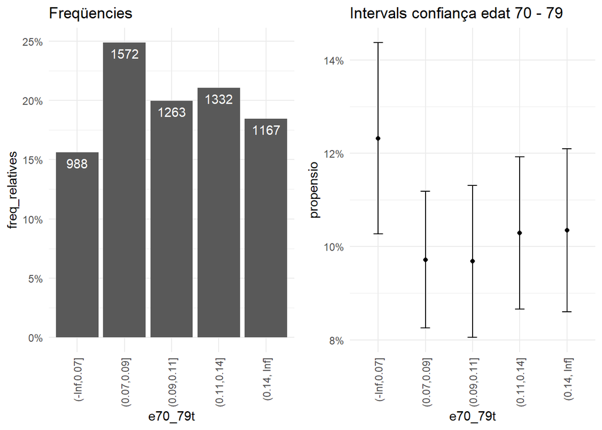

```r
p24 <- PROPEN14 %>%
  ggplot(aes(e70_79t , freq_relatives)) +
  geom_bar(stat="identity")+
  geom_text(aes(label = freq_absolutes), vjust=1.6, color="white")+
  scale_y_continuous(labels = percent)+
  theme_minimal()+
  theme(axis.text.x = element_text(angle = 90, vjust = 0.5, hjust=1))+
  labs(title="Freqüencies")

p25 <- PROPEN14 %>%
  ggplot(aes(e70_79t, propensio)) +
  geom_point(size = 1.5) +
  geom_errorbar(aes(ymin =I_minim, ymax = I_maxim, width = .2))+
  scale_y_continuous(labels = percent)+
  theme_minimal()+
  theme(axis.text.x = element_text(angle = 90, vjust = 0.5, hjust=1))+
  labs(title="Intervals confiança edat 70 - 79")

plot_grid(p24, p25, ncol=2)
```

### 2.2.2.7 Vot a Vox i edat majors 80

```r
cor(d2$M80,d2$VOX)
```

```
## [1] -0.03900435
```

```r
cor(logit(d2$M80),logit(d2$VOX), use = "pairwise.complete.obs")
```

```
## [1] -0.0001963107
```

```r
cor(d2$M80,logit(d2$VOX), use = "pairwise.complete.obs")
```

```
## [1] 0.04142835
```

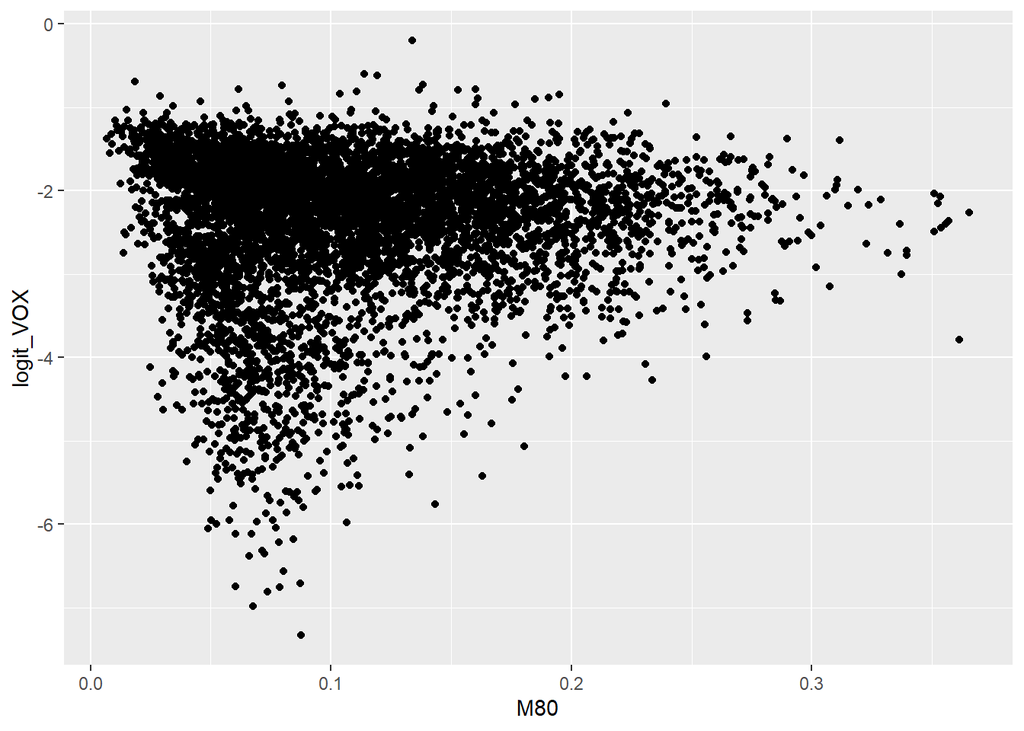

```r
d2 %>% ggplot(aes(x = M80, y = logit_VOX))+
  geom_point()
```

### Propensión del vot a Vox i majors 80 anys

```r
 quantile(d2$M80, seq(0,1,0.2))
```

```
##          0%         20%         40%         60%         80%        100%
## 0.006830601 0.056900548 0.080481155 0.112274866 0.156250000 0.365591398
```

```r
d2 <- d2 %>%
  mutate(M80t = cut(M80, c(-Inf, 0.06, 0.08, 0.11, 0.16, Inf )))

d2 %>% count(M80t)
```

```
##          M80t    n
## 1 (-Inf,0.06] 1446
## 2 (0.06,0.08] 1056
## 3 (0.08,0.11] 1218
## 4 (0.11,0.16] 1426
## 5 (0.16, Inf] 1176
```

```r
PROPEN15 <- d2 %>%
  group_by(M80t) %>%
  summarise(freq_absolutes = n()
    ,I_minim = minInt_bin(VOX )
         ,propensio = mean(VOX )
         ,I_maxim = maxInt_bin(VOX ))%>%
  mutate(freq_relatives = freq_absolutes / sum(freq_absolutes))
PROPEN15
```

```
## # A tibble: 5 x 6
##   M80t        freq_absolutes I_minim propensio I_maxim freq_relatives
##   <fct>                <int>   <dbl>     <dbl>   <dbl>          <dbl>
## 1 (-Inf,0.06]           1446  0.0976    0.114    0.130          0.229
## 2 (0.06,0.08]           1056  0.0767    0.0943   0.112          0.167
## 3 (0.08,0.11]           1218  0.0801    0.0967   0.113          0.193
## 4 (0.11,0.16]           1426  0.0906    0.107    0.123          0.226
## 5 (0.16, Inf]           1176  0.0851    0.102    0.120          0.186
```

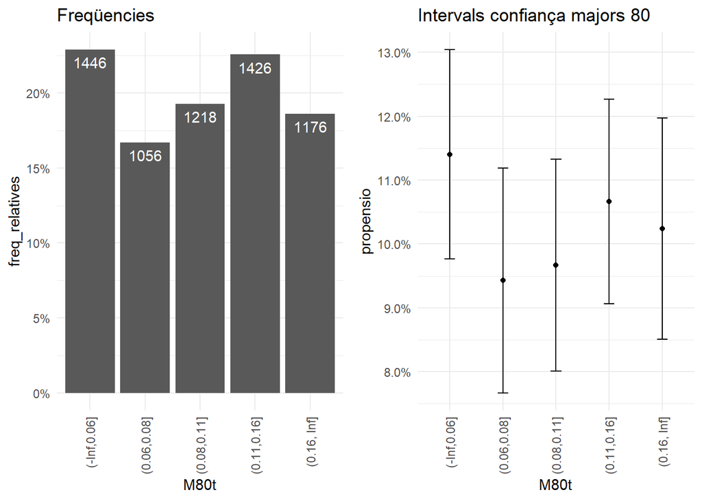

```r
p26 <- PROPEN15 %>%
  ggplot(aes(M80t , freq_relatives)) +
  geom_bar(stat="identity")+
  geom_text(aes(label = freq_absolutes), vjust=1.6, color="white")+
  scale_y_continuous(labels = percent)+
  theme_minimal()+
  theme(axis.text.x = element_text(angle = 90, vjust = 0.5, hjust=1))+
  labs(title="Freqüencies")

p27 <- PROPEN15 %>%
  ggplot(aes(M80t, propensio)) +
  geom_point(size = 1.5) +
  geom_errorbar(aes(ymin =I_minim, ymax = I_maxim, width = .2))+
  scale_y_continuous(labels = percent)+
  theme_minimal()+
  theme(axis.text.x = element_text(angle = 90, vjust = 0.5, hjust=1))+
  labs(title="Intervals confiança majors 80")

plot_grid(p26, p27, ncol=2)
```

### 2.2.3. Vot a Vox i nacionalitat

```r
d2 %>%
  mutate(logit_VOX = logit(VOX)) %>%
  select(esp, euro, asia, ame, UE, oce_apa, h, m, afr, logit_VOX, VOX) %>%
  cor()
```

```
##                   esp        euro        asia         ame          UE
## esp        1.00000000 -0.89061867 -0.35065482 -0.43835776 -0.87428196
## euro      -0.89061867  1.00000000  0.20042273  0.21294312  0.99298718
## asia      -0.35065482  0.20042273  1.00000000  0.32158037  0.17325282
## ame       -0.43835776  0.21294312  0.32158037  1.00000000  0.19164927
## UE        -0.87428196  0.99298718  0.17325282  0.19164927  1.00000000
## oce_apa   -0.09535770  0.08959280  0.04951214  0.08914346  0.08528363
## h          0.04660553 -0.02016117 -0.11837655 -0.16058520 -0.01087058
## m         -0.04660553  0.02016117  0.11837655  0.16058520  0.01087058
## afr       -0.56567846  0.17916211  0.18141695  0.22502723  0.16490349
## logit_VOX -0.01910603  0.06962309 -0.06095673 -0.07863587  0.08177046
## VOX       -0.06806519  0.09526608 -0.04590083 -0.02699317  0.10619207
##                oce_apa           h           m          afr   logit_VOX
## esp       -0.095357699  0.04660553 -0.04660553 -0.565678461 -0.01910603
## euro       0.089592805 -0.02016117  0.02016117  0.179162106  0.06962309
## asia       0.049512135 -0.11837655  0.11837655  0.181416948 -0.06095673
## ame        0.089143465 -0.16058520  0.16058520  0.225027228 -0.07863587
## UE         0.085283632 -0.01087058  0.01087058  0.164903494  0.08177046
## oce_apa    1.000000000 -0.04139945  0.04139945  0.006305305 -0.09591881
## h         -0.041399448  1.00000000 -1.00000000  0.011764574  0.10782588
## m          0.041399448 -1.00000000  1.00000000 -0.011764574 -0.10782588
## afr        0.006305305  0.01176457 -0.01176457  1.000000000 -0.04433022
## logit_VOX -0.095918814  0.10782588 -0.10782588 -0.044330220  1.00000000
## VOX       -0.065303996  0.12804547 -0.12804547  0.007056704  0.90285519
##                    VOX
## esp       -0.068065191
## euro       0.095266085
## asia      -0.045900826
## ame       -0.026993173
## UE         0.106192070
## oce_apa   -0.065303996
## h          0.128045471
## m         -0.128045471
## afr        0.007056704
## logit_VOX  0.902855191
## VOX        1.000000000
```

### 2.2.3.1 Vot a Vox i espanyols

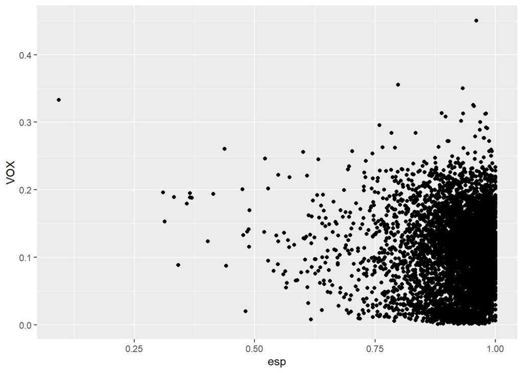

```r
d2 %>% ggplot(aes(x = esp, y = VOX))+
  geom_point()
```

### 2.2.3.2 Vot a Vox i nacionalitat europea

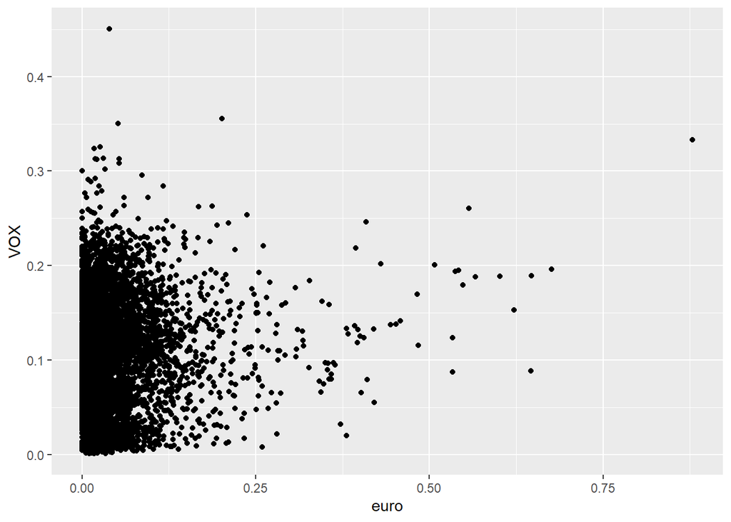

```r
d2 %>% ggplot(aes(x = euro, y = VOX))+
  geom_point()
```

### 2.2.3.3 Vot a Vox i nacionalitat asiàtica

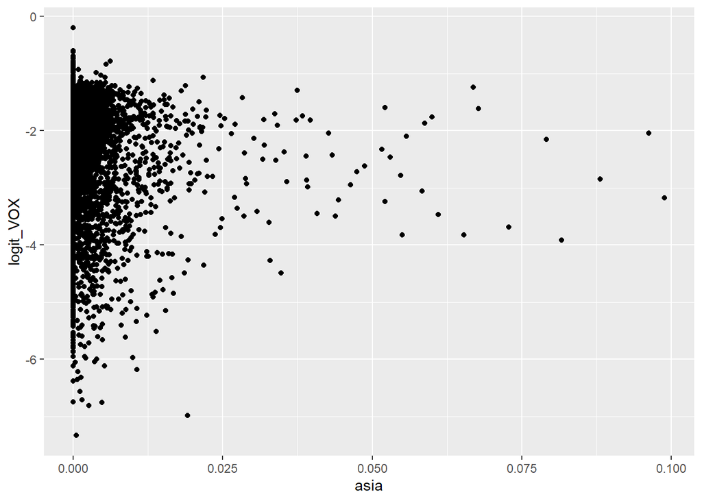

```r
d2 %>% ggplot(aes(x = asia, y = logit_VOX))+
  geom_point()
```

### 2.2.3.4 Vot a Vox i nacionalitat americana

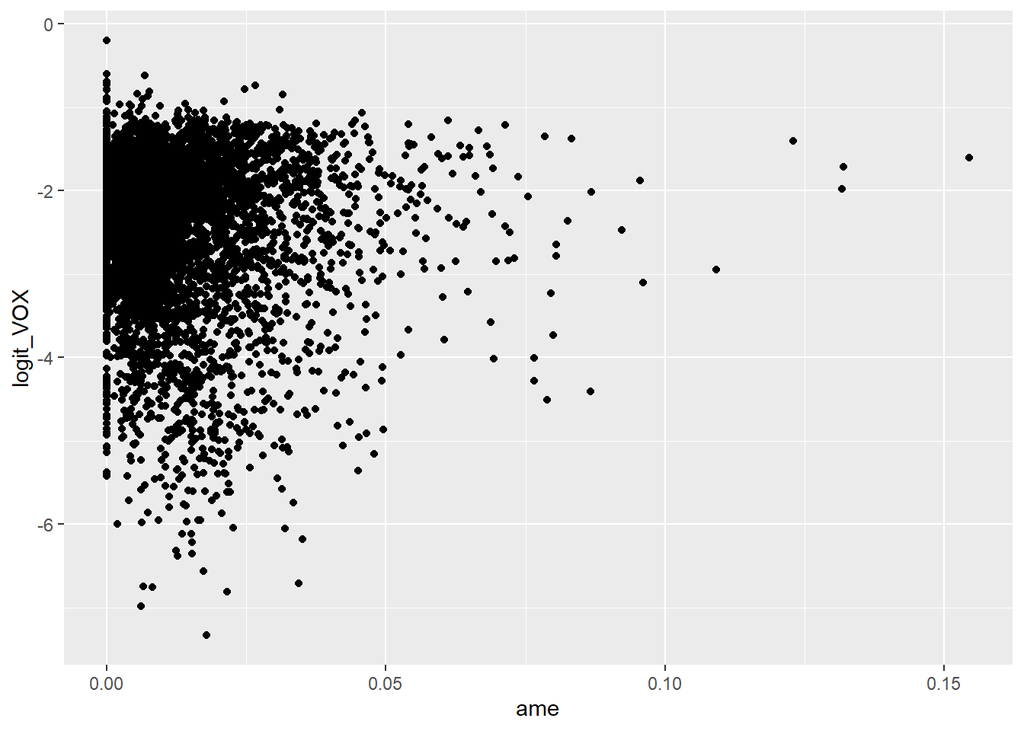

```r
d2 %>% ggplot(aes(x = ame, y = logit_VOX))+
  geom_point()
```

### 2.2.3.5 Vot a Vox i UE

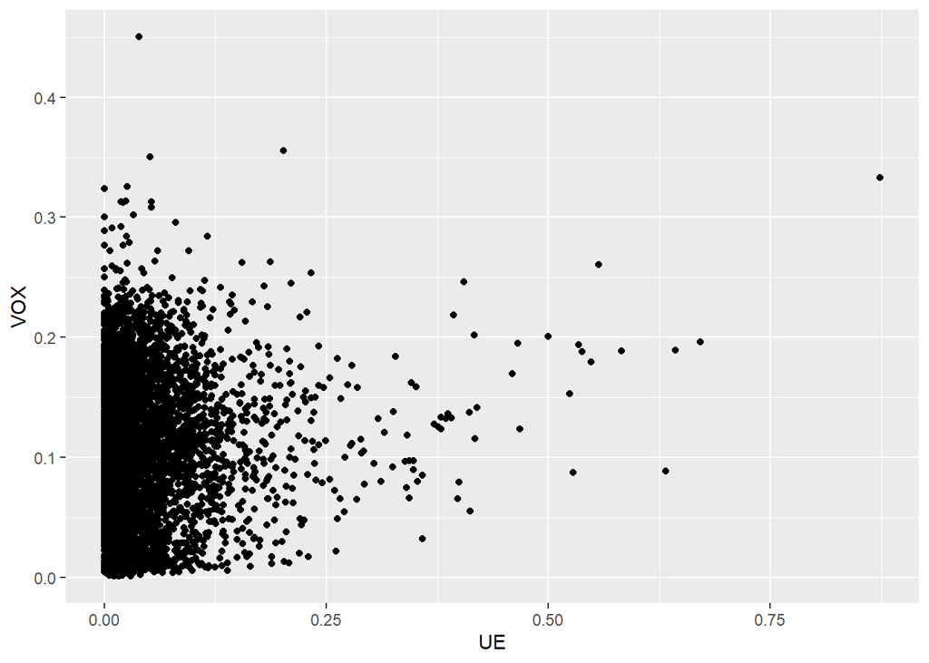

```r
d2 %>% ggplot(aes(x = UE, y = VOX))+
  geom_point()
```

### 2.2.3.6 Vot a Vox i oceania i apàtrides

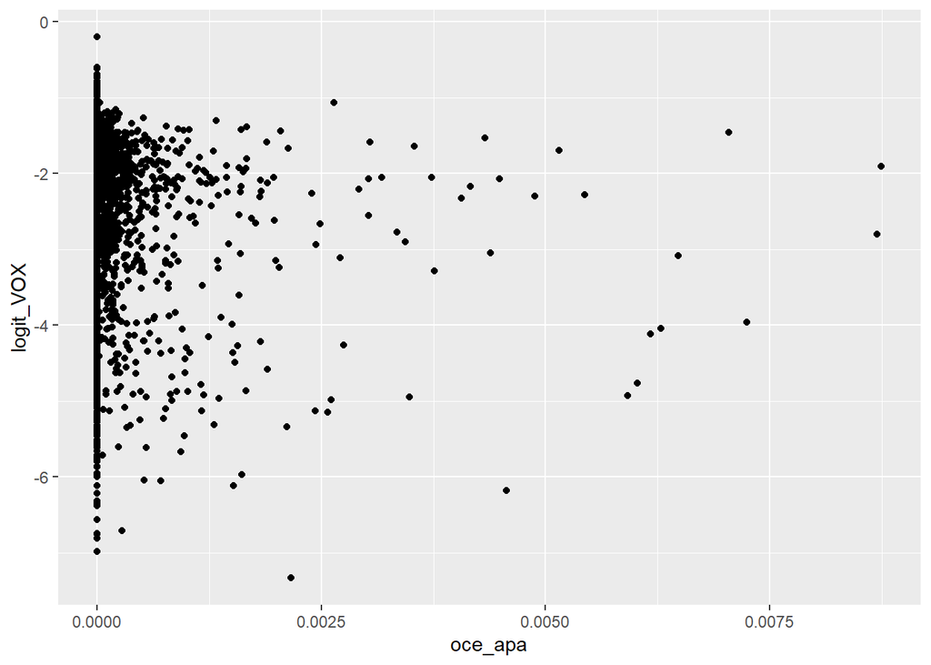

```r
d2 %>% ggplot(aes(x = oce_apa, y = logit_VOX))+
  geom_point()
```

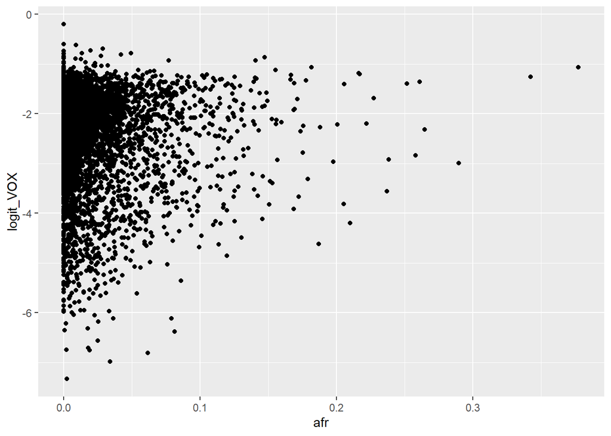

```r
d2 %>% ggplot(aes(x = afr, y = logit_VOX))+
  geom_point()
```

### 2.2.4. Vot a Vox i renta neta per persona

```r
d3 <- d2 %>% filter(VOX > -2)
```

```r
names(d2)
```

```
##  [1] "mun"                "v_blanc"            "v_nul"
##  [4] "PSOE"               "PP"                 "Cs"
##  [7] "ERC"                "VOX"                "JUNTS"
## [10] "PNV"                "PODEMOS"            "Bildu"
## [13] "BNG"                "CUP"                "atur"
## [16] "atur_m24"           "atur_25_44"         "atur_M45"
## [19] "atur_h"             "atur_d"             "pob_t"
## [22] "esp"                "euro"               "asia"
## [25] "ame"                "UE"                 "oce_apa"
## [28] "afr"                "h"                  "m"
## [31] "m19"                "e20_29"             "e30_39"
## [34] "e40_49"             "e50_59"             "e60_69"
## [37] "e70_79"             "M80"                "Renta_neta_persona"
## [40] "Gini_medio"         "Edad_media"         "Poblacion"
## [43] "tam_hog_medio"      "por_hog_uni"        "atur_t"
## [46] "atur_m24t"          "atur_25_44t"        "atur_M45t"
## [49] "logit_VOX"          "m29"                "m29t"
## [52] "e30_39t"            "e40_49t"            "e50_59t"
## [55] "e60_69t"            "e70_79t"            "M80t"
```

```r
cor(d2$Renta_neta_persona,d2$VOX)
```

```
## [1] -0.2914367
```

```r
cor(d2$Renta_neta_persona,logit(d2$VOX), use = "pairwise.complete.obs")
```

```
## [1] -0.3907623
```

```r
cor(log(d2$Renta_neta_persona),logit(d2$VOX), use = "pairwise.complete.obs")
```

```
## [1] -0.378493
```

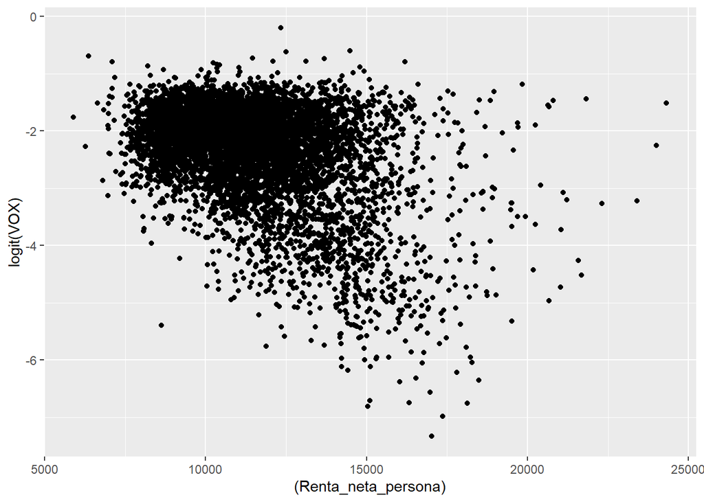

```r
d2 %>% ggplot(aes(x = (Renta_neta_persona), y = logit(VOX)))+
  geom_point()
```

######Propensió Renta neta persona

```r
 quantile(d2$Renta_neta_persona, seq(0,1,0.2))
```

```
##        0%       20%       40%       60%       80%      100%
##  5898.000  9621.834 10857.252 11920.775 13319.076 24315.911
```

```r
d2 <- d2 %>%
  mutate(Renta_neta_persona_t = cut(Renta_neta_persona, c(-Inf, 9621, 10857.252, 11920.775, 13319.076, Inf )))

d2 %>% count(Renta_neta_persona_t)
```

```
##   Renta_neta_persona_t    n
## 1      (-Inf,9.62e+03] 1264
## 2  (9.62e+03,1.09e+04] 1265
## 3  (1.09e+04,1.19e+04] 1264
## 4  (1.19e+04,1.33e+04] 1264
## 5      (1.33e+04, Inf] 1265
```

```r
PROPEN2 <- d2 %>%
  group_by(Renta_neta_persona_t) %>%
  summarise(freq_absolutes = n()
    ,I_minim = minInt_bin(VOX )
         ,propensio = mean(VOX )
         ,I_maxim = maxInt_bin(VOX ))%>%
  mutate(freq_relatives = freq_absolutes / sum(freq_absolutes))
PROPEN2
```

```
## # A tibble: 5 x 6
##   Renta_neta_persona_t freq_absolutes I_minim propensio I_maxim freq_relatives
##   <fct>                         <int>   <dbl>     <dbl>   <dbl>          <dbl>
## 1 (-Inf,9.62e+03]                1264  0.105     0.123   0.141           0.200
## 2 (9.62e+03,1.09e+04]            1265  0.0975    0.115   0.133           0.200
## 3 (1.09e+04,1.19e+04]            1264  0.0879    0.105   0.122           0.200
## 4 (1.19e+04,1.33e+04]            1264  0.0818    0.0982  0.115           0.200
## 5 (1.33e+04, Inf]                1265  0.0618    0.0764  0.0910          0.200
```

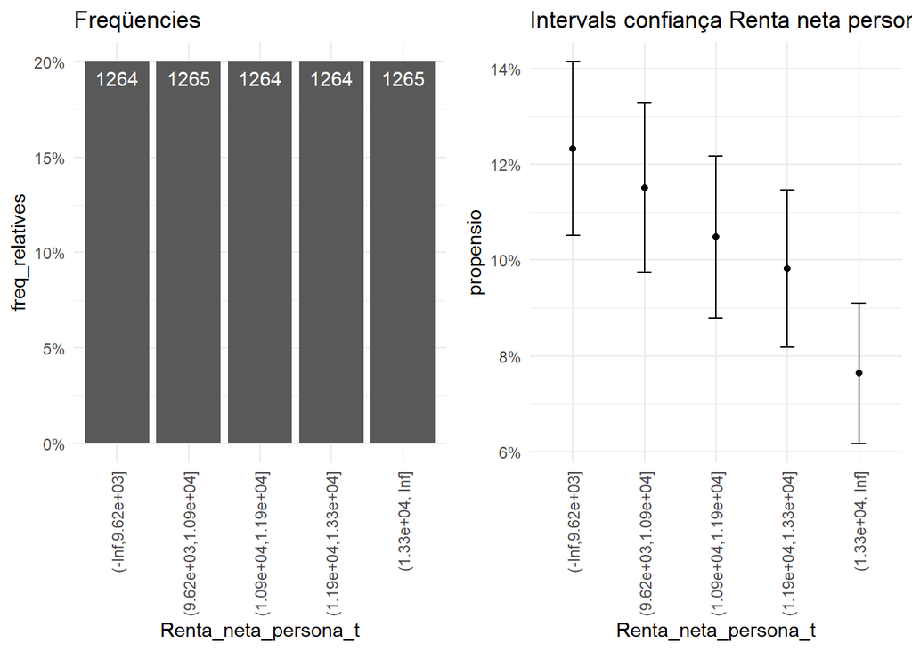

```r
p3 <- PROPEN2 %>%
  ggplot(aes(Renta_neta_persona_t , freq_relatives)) +
  geom_bar(stat="identity")+
  geom_text(aes(label = freq_absolutes), vjust=1.6, color="white")+
  scale_y_continuous(labels = percent)+
  theme_minimal()+
  theme(axis.text.x = element_text(angle = 90, vjust = 0.5, hjust=1))+
  labs(title="Freqüencies")

p4 <- PROPEN2 %>%
  ggplot(aes(Renta_neta_persona_t, propensio)) +
  geom_point(size = 1.5) +
  geom_errorbar(aes(ymin =I_minim, ymax = I_maxim, width = .2))+
  scale_y_continuous(labels = percent)+
  theme_minimal()+
  theme(axis.text.x = element_text(angle = 90, vjust = 0.5, hjust=1))+
  labs(title="Intervals confiança Renta neta persona")

plot_grid(p3, p4, ncol=2)
```

### 2.2.5. Vot a vox i índex de Gini

```r
cor(d2$Gini_medio,d2$VOX)
```

```
## [1] 0.07386005
```

```r
cor((d2$Gini_medio),logit(d2$VOX), use = "pairwise.complete.obs")
```

```
## [1] 0.03778914
```

```r
cor(log(d2$Gini_medio),logit(d2$VOX), use = "pairwise.complete.obs")
```

```
## [1] 0.03996421
```

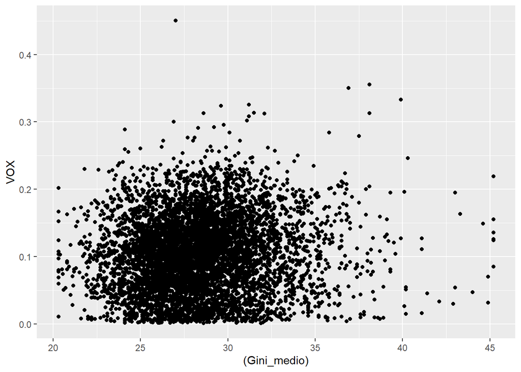

```r
d2 %>% ggplot(aes(x = (Gini_medio), y = VOX))+
  geom_point()
```

###Propensió gini medio

```r
 quantile(d2$Gini_medio, seq(0,1,0.2))
```

```
##   0%  20%  40%  60%  80% 100%
## 20.3 25.8 27.4 28.8 30.7 45.2
```

```r
d2 <- d2 %>%
  mutate(Gini_medio_t = cut(Gini_medio, c(-Inf, 25.8, 27.4, 28.8, 30.7, Inf )))

d2 %>% count(Gini_medio_t)
```

```
##   Gini_medio_t    n
## 1  (-Inf,25.8] 1288
## 2  (25.8,27.4] 1252
## 3  (27.4,28.8] 1280
## 4  (28.8,30.7] 1261
## 5  (30.7, Inf] 1241
```

```r
PROPEN3 <- d2 %>%
  group_by(Gini_medio_t) %>%
  summarise(freq_absolutes = n()
    ,I_minim = minInt_bin(VOX )
         ,propensio = mean(VOX )
         ,I_maxim = maxInt_bin(VOX ))%>%
  mutate(freq_relatives = freq_absolutes / sum(freq_absolutes))
PROPEN3
```

```
## # A tibble: 5 x 6
##   Gini_medio_t freq_absolutes I_minim propensio I_maxim freq_relatives
##   <fct>                 <int>   <dbl>     <dbl>   <dbl>          <dbl>
## 1 (-Inf,25.8]            1288  0.0808    0.0970   0.113          0.204
## 2 (25.8,27.4]            1252  0.0825    0.0990   0.116          0.198
## 3 (27.4,28.8]            1280  0.0871    0.104    0.121          0.202
## 4 (28.8,30.7]            1261  0.0933    0.111    0.128          0.199
## 5 (30.7, Inf]            1241  0.0903    0.108    0.125          0.196
```

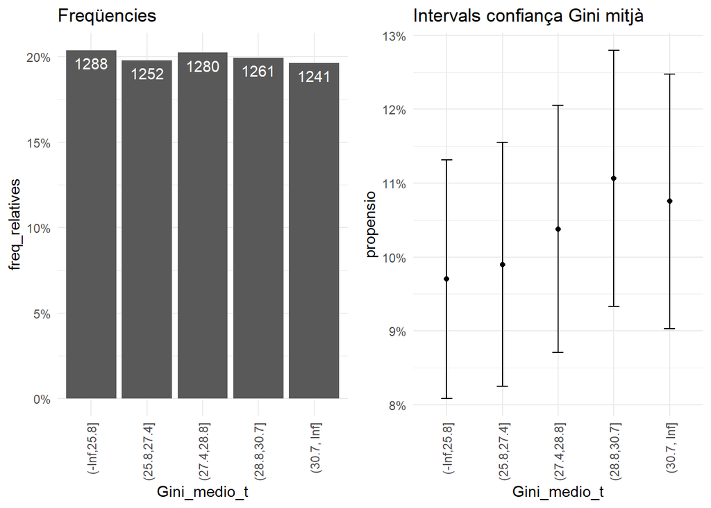

```r
p5 <- PROPEN3 %>%
  ggplot(aes(Gini_medio_t , freq_relatives)) +
  geom_bar(stat="identity")+
  geom_text(aes(label = freq_absolutes), vjust=1.6, color="white")+
  scale_y_continuous(labels = percent)+
  theme_minimal()+
  theme(axis.text.x = element_text(angle = 90, vjust = 0.5, hjust=1))+
  labs(title="Freqüencies")

p6 <- PROPEN3 %>%
  ggplot(aes(Gini_medio_t, propensio)) +
  geom_point(size = 1.5) +
  geom_errorbar(aes(ymin =I_minim, ymax = I_maxim, width = .2))+
  scale_y_continuous(labels = percent)+
  theme_minimal()+
  theme(axis.text.x = element_text(angle = 90, vjust = 0.5, hjust=1))+
  labs(title="Intervals confiança Gini mitjà")

plot_grid(p5, p6, ncol=2)
```

### 2.2.6. Vot a Vox i tamany mig de la llar

```r
cor(d2$tam_hog_medio,d2$VOX)
```

```
## [1] -0.02738314
```

```r
cor((d2$tam_hog_medio),logit(d2$VOX), use = "pairwise.complete.obs")
```

```
## [1] -0.1037847
```

```r
cor(log(d2$tam_hog_medio),logit(d2$VOX), use = "pairwise.complete.obs")
```

```
## [1] -0.1046679
```

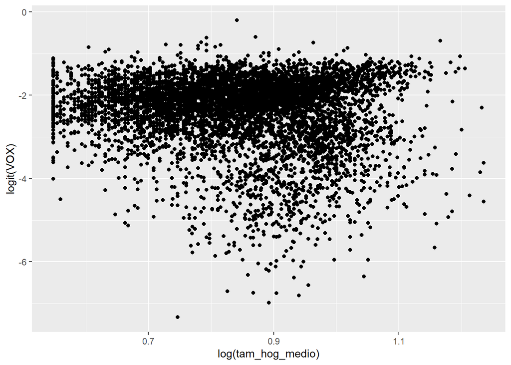

```r
d2 %>% ggplot(aes(x = log(tam_hog_medio), y = logit(VOX)))+
  geom_point()
```

###Propensió tamany mig de la llar

```r
 quantile(d2$tam_hog_medio, seq(0,1,0.2))
```

```
##       0%      20%      40%      60%      80%     100%
## 1.730000 2.080000 2.265085 2.430000 2.611497 3.440000
```

```r
d2 <- d2 %>%
  mutate(tam_hog_medio = cut(tam_hog_medio, c(-Inf, 2.08, 2.27, 2.43, 2.61, Inf )))

d2 %>% count(tam_hog_medio)
```

```
##   tam_hog_medio    n
## 1   (-Inf,2.08] 1304
## 2   (2.08,2.27] 1311
## 3   (2.27,2.43] 1213
## 4   (2.43,2.61] 1221
## 5   (2.61, Inf] 1273
```

```r
PROPEN7 <- d2 %>%
  group_by(tam_hog_medio) %>%
  summarise(freq_absolutes = n()
    ,I_minim = minInt_bin(VOX )
         ,propensio = mean(VOX )
         ,I_maxim = maxInt_bin(VOX ))%>%
  mutate(freq_relatives = freq_absolutes / sum(freq_absolutes))
PROPEN7
```

```
## # A tibble: 5 x 6
##   tam_hog_medio freq_absolutes I_minim propensio I_maxim freq_relatives
##   <fct>                  <int>   <dbl>     <dbl>   <dbl>          <dbl>
## 1 (-Inf,2.08]             1304  0.0898    0.107    0.123          0.206
## 2 (2.08,2.27]             1311  0.0903    0.107    0.124          0.207
## 3 (2.27,2.43]             1213  0.0853    0.102    0.119          0.192
## 4 (2.43,2.61]             1221  0.0824    0.0991   0.116          0.193
## 5 (2.61, Inf]             1273  0.0857    0.102    0.119          0.201
```

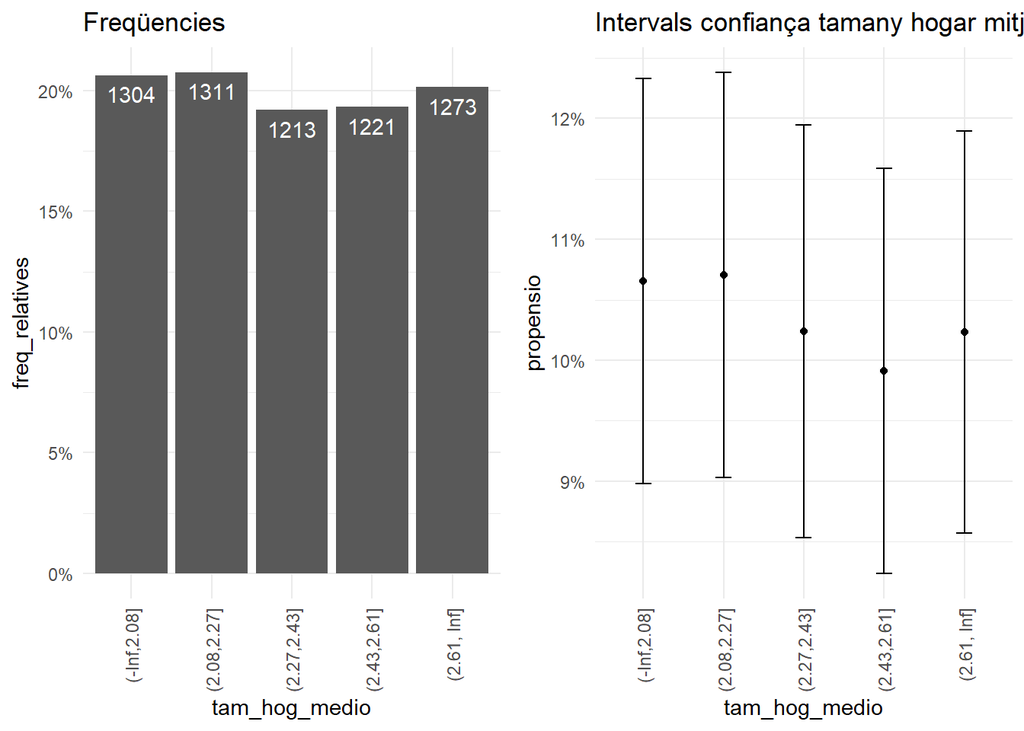

```r
p10 <- PROPEN7 %>%
  ggplot(aes(tam_hog_medio , freq_relatives)) +
  geom_bar(stat="identity")+
  geom_text(aes(label = freq_absolutes), vjust=1.6, color="white")+
  scale_y_continuous(labels = percent)+
  theme_minimal()+
  theme(axis.text.x = element_text(angle = 90, vjust = 0.5, hjust=1))+
  labs(title="Freqüencies")

p11 <- PROPEN7 %>%
  ggplot(aes(tam_hog_medio, propensio)) +
  geom_point(size = 1.5) +
  geom_errorbar(aes(ymin =I_minim, ymax = I_maxim, width = .2))+
  scale_y_continuous(labels = percent)+
  theme_minimal()+
  theme(axis.text.x = element_text(angle = 90, vjust = 0.5, hjust=1))+
  labs(title="Intervals confiança tamany hogar mitjà")

plot_grid(p10, p11, ncol=2)
```

### 2.2.7. Vot a Vox i llars unipersonals

```r
class((d2$por_hog_uni))
```

```
## [1] "numeric"
```

```r
cor(d2$por_hog_uni,d2$VOX)
```

```
## [1] 0.03709287
```

```r
cor((d2$por_hog_uni),logit(d2$VOX), use = "pairwise.complete.obs")
```

```
## [1] 0.09487254
```

```r
cor(log(d2$por_hog_uni),logit(d2$VOX), use = "pairwise.complete.obs")
```

```
## [1] 0.09039445
```

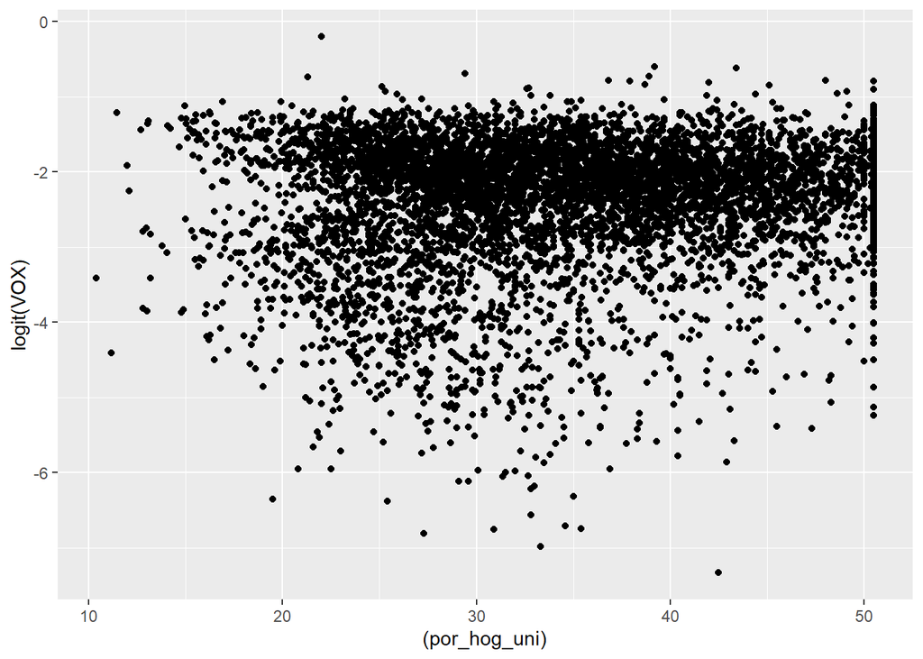

```r
d2 %>% ggplot(aes(x = (por_hog_uni), y = logit(VOX)))+
  geom_point()
```

### 2.2.8. Propensió del vot a VOX i llars unipersonals

```r
 quantile(d2$por_hog_uni, seq(0,1,0.2))
```

```
##       0%      20%      40%      60%      80%     100%
## 10.40000 26.09400 31.04068 36.37524 42.90000 50.50000
```

```r
d2 <- d2 %>%
  mutate(por_hog_unit = cut(por_hog_uni, c(-Inf, 26.09, 31.04, 36.38, 42.9, Inf )))

d2 %>% count(por_hog_unit)
```

```
##   por_hog_unit    n
## 1  (-Inf,26.1] 1263
## 2    (26.1,31] 1265
## 3    (31,36.4] 1265
## 4  (36.4,42.9] 1269
## 5  (42.9, Inf] 1260
```

```r
PROPEN8 <- d2 %>%
  group_by(por_hog_unit) %>%
  summarise(freq_absolutes = n()
    ,I_minim = minInt_bin(VOX )
         ,propensio = mean(VOX )
         ,I_maxim = maxInt_bin(VOX ))%>%
  mutate(freq_relatives = freq_absolutes / sum(freq_absolutes))
PROPEN8
```

```
## # A tibble: 5 x 6
##   por_hog_unit freq_absolutes I_minim propensio I_maxim freq_relatives
##   <fct>                 <int>   <dbl>     <dbl>   <dbl>          <dbl>
## 1 (-Inf,26.1]            1263  0.0853    0.102    0.119          0.200
## 2 (26.1,31]              1265  0.0830    0.0995   0.116          0.200
## 3 (31,36.4]              1265  0.0876    0.104    0.121          0.200
## 4 (36.4,42.9]            1269  0.0883    0.105    0.122          0.201
## 5 (42.9, Inf]            1260  0.0896    0.107    0.124          0.199
```

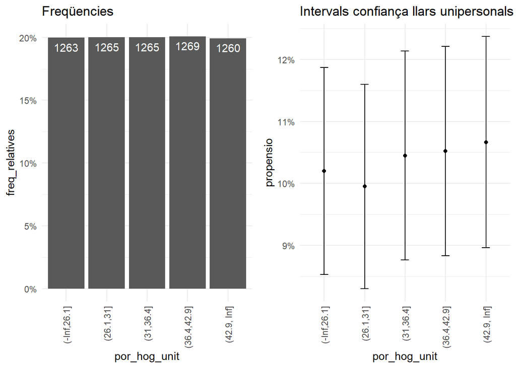

```r
p12 <- PROPEN8 %>%
  ggplot(aes(por_hog_unit , freq_relatives)) +
  geom_bar(stat="identity")+
  geom_text(aes(label = freq_absolutes), vjust=1.6, color="white")+
  scale_y_continuous(labels = percent)+
  theme_minimal()+
  theme(axis.text.x = element_text(angle = 90, vjust = 0.5, hjust=1))+
  labs(title="Freqüencies")

p13 <- PROPEN8 %>%
  ggplot(aes(por_hog_unit, propensio)) +
  geom_point(size = 1.5) +
  geom_errorbar(aes(ymin =I_minim, ymax = I_maxim, width = .2))+
  scale_y_continuous(labels = percent)+
  theme_minimal()+
  theme(axis.text.x = element_text(angle = 90, vjust = 0.5, hjust=1))+
  labs(title="Intervals confiança llars unipersonals")

plot_grid(p12, p13, ncol=2)
```

## 2.3. Anàlisi multivariant

Primer fem un model amb totes les variables, per veure quines són significatives i quines no. Utilitzarem només les generals.

```r
model0 <- lm(logit(VOX) ~ atur + euro + asia + ame + oce_apa + afr + h + m + m19 + Renta_neta_persona + esp + pob_t + UE + e20_29 + e30_39 + e40_49 + e50_59 + e60_69 + e70_79 + M80 + Gini_medio + tam_hog_medio + por_hog_uni, data=d2)
summary(model0)
```

```
##
## Call:
## lm(formula = logit(VOX) ~ atur + euro + asia + ame + oce_apa +
##     afr + h + m + m19 + Renta_neta_persona + esp + pob_t + UE +
##     e20_29 + e30_39 + e40_49 + e50_59 + e60_69 + e70_79 + M80 +
##     Gini_medio + tam_hog_medio + por_hog_uni, data = d2)
##
## Residuals:
##     Min      1Q  Median      3Q     Max
## -3.6012 -0.4009  0.1134  0.5006  3.0031
##
## Coefficients: (2 not defined because of singularities)
##                            Estimate Std. Error t value Pr(>|t|)
## (Intercept)              -5.725e+00  9.381e-01  -6.103 1.11e-09 ***
## atur                      1.331e+00  3.057e-01   4.353 1.37e-05 ***
## euro                     -5.775e+00  1.455e+00  -3.970 7.26e-05 ***
## asia                     -3.597e+00  1.899e+00  -1.895  0.05817 .
## ame                      -4.986e-01  9.160e-01  -0.544  0.58620
## oce_apa                  -1.234e+02  2.382e+01  -5.181 2.27e-07 ***
## afr                      -2.355e+00  3.876e-01  -6.076 1.31e-09 ***
## h                         4.436e+00  3.883e-01  11.425  < 2e-16 ***
## m                                NA         NA      NA       NA
## m19                      -2.152e+00  1.156e+00  -1.862  0.06269 .
## Renta_neta_persona       -1.503e-04  6.145e-06 -24.451  < 2e-16 ***
## esp                              NA         NA      NA       NA
## pob_t                     9.484e-07  1.845e-07   5.139 2.84e-07 ***
## UE                        6.791e+00  1.514e+00   4.485 7.42e-06 ***
## e20_29                    3.414e+00  1.172e+00   2.914  0.00358 **
## e30_39                    6.292e+00  9.759e-01   6.447 1.22e-10 ***
## e40_49                    6.403e+00  1.077e+00   5.943 2.95e-09 ***
## e50_59                    3.079e+00  1.070e+00   2.877  0.00403 **
## e60_69                   -4.930e-01  9.923e-01  -0.497  0.61933
## e70_79                    6.429e-01  1.007e+00   0.639  0.52303
## M80                       2.733e+00  9.669e-01   2.826  0.00472 **
## Gini_medio                2.298e-02  3.545e-03   6.483 9.68e-11 ***
## tam_hog_medio(2.08,2.27] -1.165e-01  3.643e-02  -3.197  0.00139 **
## tam_hog_medio(2.27,2.43] -2.154e-01  4.771e-02  -4.516 6.42e-06 ***
## tam_hog_medio(2.43,2.61] -3.069e-01  5.898e-02  -5.204 2.01e-07 ***
## tam_hog_medio(2.61, Inf] -2.361e-01  7.345e-02  -3.215  0.00131 **
## por_hog_uni              -9.168e-03  2.833e-03  -3.237  0.00122 **
## ---
## Signif. codes:  0 '***' 0.001 '**' 0.01 '*' 0.05 '.' 0.1 ' ' 1
##
## Residual standard error: 0.756 on 6297 degrees of freedom
## Multiple R-squared:  0.2461, Adjusted R-squared:  0.2432
## F-statistic: 85.64 on 24 and 6297 DF,  p-value: < 2.2e-16
```

```r
model01 <- lm(logit(VOX) ~ atur + euro + asia  + oce_apa + afr + h + m + Renta_neta_persona + esp + pob_t + UE + e20_29 + e30_39 + e40_49 + e50_59 + M80 + Gini_medio, data=d2)
summary(model01)
```

```
##
## Call:
## lm(formula = logit(VOX) ~ atur + euro + asia + oce_apa + afr +
##     h + m + Renta_neta_persona + esp + pob_t + UE + e20_29 +
##     e30_39 + e40_49 + e50_59 + M80 + Gini_medio, data = d2)
##
## Residuals:
##     Min      1Q  Median      3Q     Max
## -3.6118 -0.3974  0.1170  0.4926  3.0665
##
## Coefficients: (1 not defined because of singularities)
##                      Estimate Std. Error t value Pr(>|t|)
## (Intercept)        -7.345e+00  9.699e-01  -7.573 4.17e-14 ***
## atur                1.557e+00  3.021e-01   5.153 2.64e-07 ***
## euro               -5.077e+00  1.791e+00  -2.835  0.00459 **
## asia               -3.402e+00  2.245e+00  -1.515  0.12981
## oce_apa            -1.290e+02  2.394e+01  -5.389 7.35e-08 ***
## afr                -2.142e+00  1.018e+00  -2.104  0.03543 *
## h                   5.008e+00  3.546e-01  14.121  < 2e-16 ***
## m                          NA         NA      NA       NA
## Renta_neta_persona -1.493e-04  5.985e-06 -24.948  < 2e-16 ***
## esp                 7.201e-01  9.129e-01   0.789  0.43024
## pob_t               9.910e-07  1.852e-07   5.351 9.05e-08 ***
## UE                  6.985e+00  1.520e+00   4.595 4.41e-06 ***
## e20_29              3.137e+00  5.444e-01   5.762 8.69e-09 ***
## e30_39              5.352e+00  5.128e-01  10.436  < 2e-16 ***
## e40_49              5.569e+00  4.709e-01  11.827  < 2e-16 ***
## e50_59              3.299e+00  4.392e-01   7.512 6.64e-14 ***
## M80                 3.759e+00  3.527e-01  10.659  < 2e-16 ***
## Gini_medio          2.206e-02  3.464e-03   6.366 2.07e-10 ***
## ---
## Signif. codes:  0 '***' 0.001 '**' 0.01 '*' 0.05 '.' 0.1 ' ' 1
##
## Residual standard error: 0.7598 on 6305 degrees of freedom
## Multiple R-squared:  0.2375, Adjusted R-squared:  0.2355
## F-statistic: 122.7 on 16 and 6305 DF,  p-value: < 2.2e-16
```

```r
model02 <- lm(logit(VOX) ~ atur + euro  + oce_apa + afr + h + Renta_neta_persona + pob_t + UE + e20_29 + e30_39 + e40_49 + e50_59 + M80 + Gini_medio, data=d2)
summary(model02)
```

```
##
## Call:
## lm(formula = logit(VOX) ~ atur + euro + oce_apa + afr + h + Renta_neta_persona +
##     pob_t + UE + e20_29 + e30_39 + e40_49 + e50_59 + M80 + Gini_medio,
##     data = d2)
##
## Residuals:
##     Min      1Q  Median      3Q     Max
## -3.6012 -0.3981  0.1166  0.4933  3.0549
##
## Coefficients:
##                      Estimate Std. Error t value Pr(>|t|)
## (Intercept)        -6.608e+00  2.714e-01 -24.344  < 2e-16 ***
## atur                1.559e+00  3.019e-01   5.164 2.50e-07 ***
## euro               -6.578e+00  1.426e+00  -4.613 4.05e-06 ***
## oce_apa            -1.309e+02  2.389e+01  -5.479 4.45e-08 ***
## afr                -2.958e+00  3.750e-01  -7.887 3.63e-15 ***
## h                   5.067e+00  3.525e-01  14.373  < 2e-16 ***
## Renta_neta_persona -1.507e-04  5.935e-06 -25.396  < 2e-16 ***
## pob_t               9.086e-07  1.820e-07   4.993 6.12e-07 ***
## UE                  7.732e+00  1.490e+00   5.190 2.17e-07 ***
## e20_29              3.028e+00  5.419e-01   5.588 2.39e-08 ***
## e30_39              5.271e+00  5.093e-01  10.351  < 2e-16 ***
## e40_49              5.500e+00  4.671e-01  11.776  < 2e-16 ***
## e50_59              3.354e+00  4.386e-01   7.647 2.36e-14 ***
## M80                 3.760e+00  3.524e-01  10.671  < 2e-16 ***
## Gini_medio          2.127e-02  3.412e-03   6.234 4.83e-10 ***
## ---
## Signif. codes:  0 '***' 0.001 '**' 0.01 '*' 0.05 '.' 0.1 ' ' 1
##
## Residual standard error: 0.7601 on 6307 degrees of freedom
## Multiple R-squared:  0.2367, Adjusted R-squared:  0.235
## F-statistic: 139.7 on 14 and 6307 DF,  p-value: < 2.2e-16
```

```r
model03 <- lm(logit(VOX) ~ atur + atur_m24 + atur_25_44 + atur_M45 + atur_h + atur_d + euro  + oce_apa + afr + h + Renta_neta_persona + pob_t + UE + e20_29 + e30_39 + e40_49 + e50_59 + M80 + Gini_medio, data=d2)
summary(model03)
```

```
##
## Call:
## lm(formula = logit(VOX) ~ atur + atur_m24 + atur_25_44 + atur_M45 +
##     atur_h + atur_d + euro + oce_apa + afr + h + Renta_neta_persona +
##     pob_t + UE + e20_29 + e30_39 + e40_49 + e50_59 + M80 + Gini_medio,
##     data = d2)
##
## Residuals:
##     Min      1Q  Median      3Q     Max
## -3.5816 -0.3843  0.1051  0.4844  3.0694
##
## Coefficients:
##                      Estimate Std. Error t value Pr(>|t|)
## (Intercept)        -6.613e+00  2.860e-01 -23.125  < 2e-16 ***
## atur                1.915e+01  5.499e+00   3.483 0.000500 ***
## atur_m24            1.675e+00  3.625e-01   4.620 3.91e-06 ***
## atur_25_44         -1.824e-01  1.003e+00  -0.182 0.855714
## atur_M45            1.176e+00  1.469e+00   0.801 0.423324
## atur_h             -1.403e+01  2.624e+00  -5.348 9.20e-08 ***
## atur_d             -7.180e+00  2.021e+00  -3.553 0.000384 ***
## euro               -6.329e+00  1.416e+00  -4.469 7.99e-06 ***
## oce_apa            -1.277e+02  2.369e+01  -5.390 7.28e-08 ***
## afr                -2.946e+00  3.731e-01  -7.896 3.36e-15 ***
## h                   5.108e+00  3.785e-01  13.495  < 2e-16 ***
## Renta_neta_persona -1.514e-04  5.923e-06 -25.555  < 2e-16 ***
## pob_t               9.609e-07  1.806e-07   5.320 1.07e-07 ***
## UE                  7.555e+00  1.479e+00   5.109 3.34e-07 ***
## e20_29              2.339e+00  5.442e-01   4.298 1.75e-05 ***
## e30_39              4.961e+00  5.063e-01   9.798  < 2e-16 ***
## e40_49              5.272e+00  4.651e-01  11.334  < 2e-16 ***
## e50_59              3.546e+00  4.376e-01   8.104 6.36e-16 ***
## M80                 3.785e+00  3.555e-01  10.648  < 2e-16 ***
## Gini_medio          2.535e-02  3.409e-03   7.438 1.16e-13 ***
## ---
## Signif. codes:  0 '***' 0.001 '**' 0.01 '*' 0.05 '.' 0.1 ' ' 1
##
## Residual standard error: 0.7535 on 6302 degrees of freedom
## Multiple R-squared:  0.2505, Adjusted R-squared:  0.2482
## F-statistic: 110.9 on 19 and 6302 DF,  p-value: < 2.2e-16
```

```r
model04 <- lm(logit(VOX) ~ atur + atur_m24 + atur_h + atur_d + euro  + oce_apa + afr + h + Renta_neta_persona + UE + pob_t + e20_29 + e30_39 + e40_49 + e50_59 + M80 + Gini_medio, data=d2)
summary(model04)
```

```
##
## Call:
## lm(formula = logit(VOX) ~ atur + atur_m24 + atur_h + atur_d +
##     euro + oce_apa + afr + h + Renta_neta_persona + UE + pob_t +
##     e20_29 + e30_39 + e40_49 + e50_59 + M80 + Gini_medio, data = d2)
##
## Residuals:
##     Min      1Q  Median      3Q     Max
## -3.5801 -0.3831  0.1065  0.4851  3.0711
##
## Coefficients:
##                      Estimate Std. Error t value Pr(>|t|)
## (Intercept)        -6.663e+00  2.851e-01 -23.372  < 2e-16 ***
## atur                2.121e+01  4.556e+00   4.655 3.30e-06 ***
## atur_m24            1.449e+00  2.543e-01   5.698 1.26e-08 ***
## atur_h             -1.445e+01  2.609e+00  -5.539 3.17e-08 ***
## atur_d             -7.464e+00  2.015e+00  -3.704 0.000214 ***
## euro               -6.181e+00  1.414e+00  -4.370 1.26e-05 ***
## oce_apa            -1.277e+02  2.369e+01  -5.390 7.30e-08 ***
## afr                -2.908e+00  3.721e-01  -7.815 6.42e-15 ***
## h                   5.158e+00  3.775e-01  13.665  < 2e-16 ***
## Renta_neta_persona -1.500e-04  5.893e-06 -25.459  < 2e-16 ***
## UE                  7.421e+00  1.478e+00   5.022 5.26e-07 ***
## pob_t               9.653e-07  1.806e-07   5.347 9.28e-08 ***
## e20_29              2.365e+00  5.412e-01   4.371 1.26e-05 ***
## e30_39              4.994e+00  5.062e-01   9.866  < 2e-16 ***
## e40_49              5.331e+00  4.637e-01  11.497  < 2e-16 ***
## e50_59              3.464e+00  4.355e-01   7.956 2.10e-15 ***
## M80                 3.841e+00  3.536e-01  10.863  < 2e-16 ***
## Gini_medio          2.507e-02  3.403e-03   7.367 1.97e-13 ***
## ---
## Signif. codes:  0 '***' 0.001 '**' 0.01 '*' 0.05 '.' 0.1 ' ' 1
##
## Residual standard error: 0.7537 on 6304 degrees of freedom
## Multiple R-squared:  0.2499, Adjusted R-squared:  0.2479
## F-statistic: 123.6 on 17 and 6304 DF,  p-value: < 2.2e-16
```

###Tot sembla indicar que el millor model on totes les variables introduides són significatives i amb un adjust de 24’99% és el model 04. Les variables escollides són les que presentaven una major correlació amb la variable vot a VOX.

```r
model05 <- lm(VOX ~ atur + atur_m24 + atur_h + atur_d + euro  + oce_apa + afr + h + Renta_neta_persona + UE + pob_t + e20_29 + e30_39 + e40_49 + e50_59 + M80 + Gini_medio, data=d2)
summary(model05)
```

```
##
## Call:
## lm(formula = VOX ~ atur + atur_m24 + atur_h + atur_d + euro +
##     oce_apa + afr + h + Renta_neta_persona + UE + pob_t + e20_29 +
##     e30_39 + e40_49 + e50_59 + M80 + Gini_medio, data = d2)
##
## Residuals:
##      Min       1Q   Median       3Q      Max
## -0.15573 -0.03782 -0.00317  0.03140  0.32571
##
## Coefficients:
##                      Estimate Std. Error t value Pr(>|t|)
## (Intercept)        -2.183e-01  1.905e-02 -11.458  < 2e-16 ***
## atur                1.301e+00  3.045e-01   4.271 1.97e-05 ***
## atur_m24            8.839e-02  1.700e-02   5.200 2.06e-07 ***
## atur_h             -9.686e-01  1.744e-01  -5.554 2.90e-08 ***
## atur_d             -4.089e-01  1.347e-01  -3.036 0.002408 **
## euro               -4.651e-01  9.453e-02  -4.920 8.86e-07 ***
## oce_apa            -5.966e+00  1.584e+00  -3.767 0.000167 ***
## afr                -1.239e-01  2.487e-02  -4.984 6.41e-07 ***
## h                   3.791e-01  2.523e-02  15.026  < 2e-16 ***
## Renta_neta_persona -7.255e-06  3.939e-07 -18.418  < 2e-16 ***
## UE                  5.562e-01  9.876e-02   5.632 1.86e-08 ***
## pob_t               4.186e-08  1.207e-08   3.469 0.000526 ***
## e20_29              1.578e-01  3.617e-02   4.362 1.31e-05 ***
## e30_39              3.435e-01  3.383e-02  10.154  < 2e-16 ***
## e40_49              3.315e-01  3.099e-02  10.697  < 2e-16 ***
## e50_59              1.746e-01  2.910e-02   5.998 2.11e-09 ***
## M80                 1.850e-01  2.363e-02   7.829 5.71e-15 ***
## Gini_medio          1.863e-03  2.275e-04   8.191 3.12e-16 ***
## ---
## Signif. codes:  0 '***' 0.001 '**' 0.01 '*' 0.05 '.' 0.1 ' ' 1
##
## Residual standard error: 0.05037 on 6304 degrees of freedom
## Multiple R-squared:  0.1976, Adjusted R-squared:  0.1955
## F-statistic: 91.33 on 17 and 6304 DF,  p-value: < 2.2e-16
```

###El model 05 és el mateix, pero sense transformar la variable VOX a logit. Es pot apreciar que l’adjust cau força. ###A continuació realitzem una revisió dels residus de la regressió:

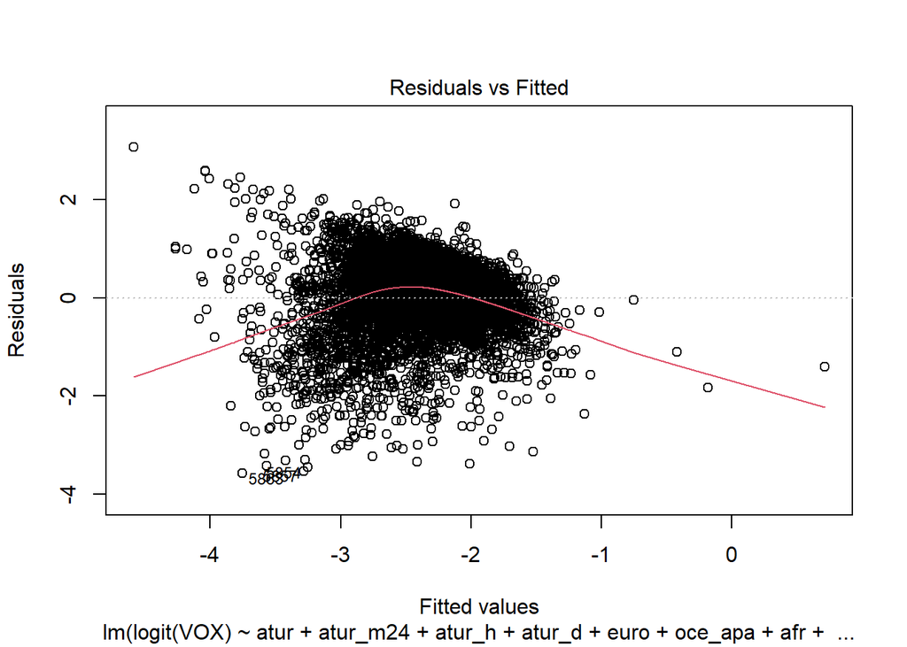

```r
plot(model04,1)
```

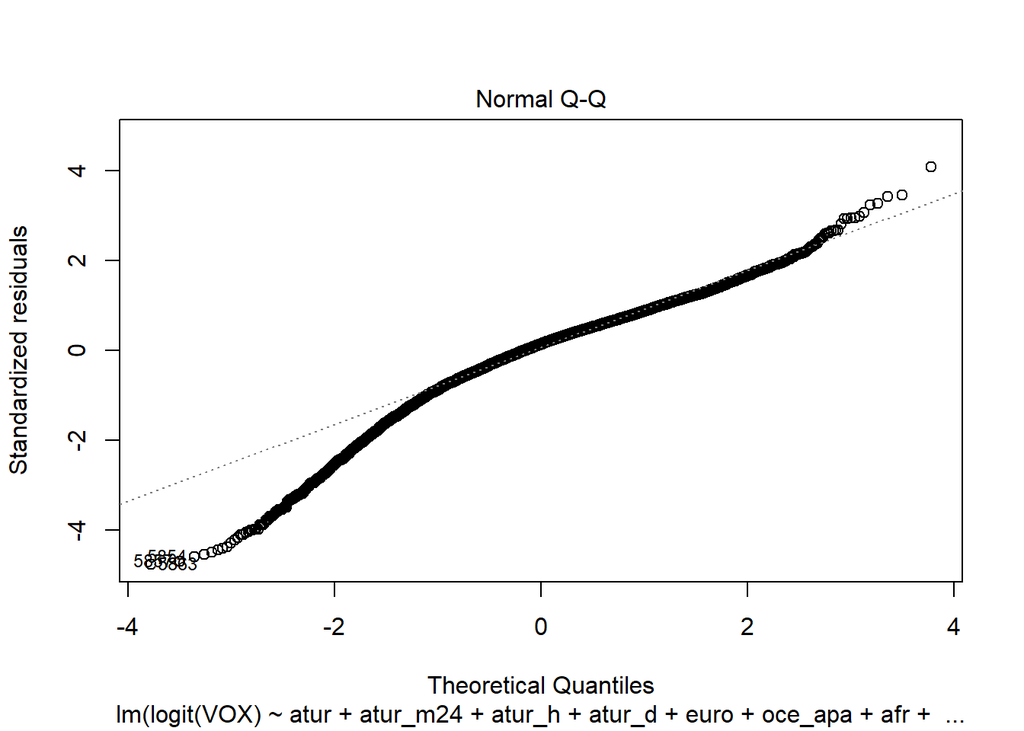

```r
plot(model04,2)
```

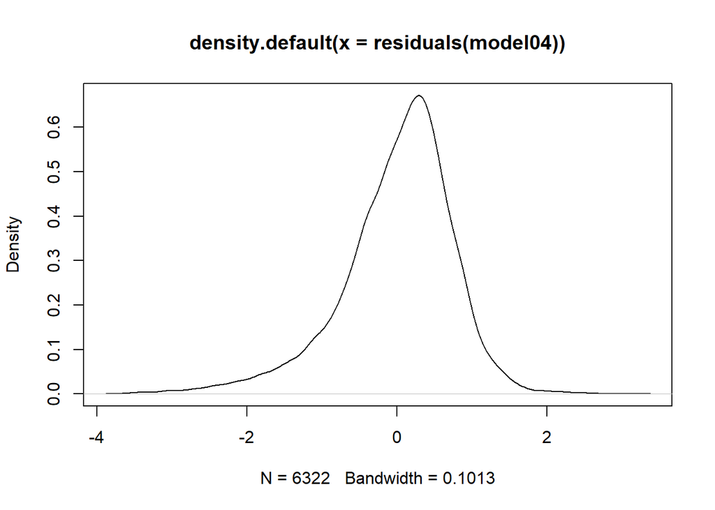

```r
plot(density(residuals(model04)))
```

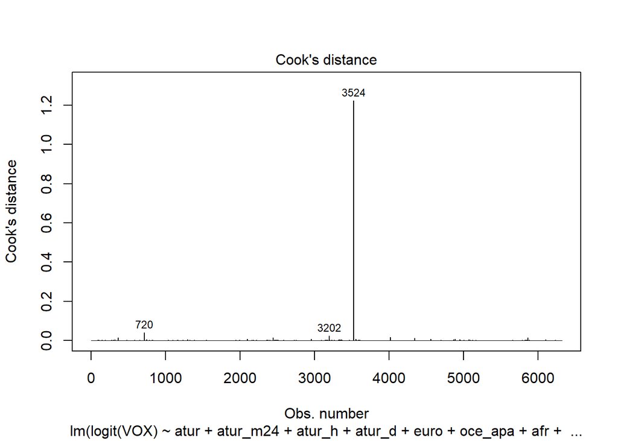

```r
plot(model04,4)
```

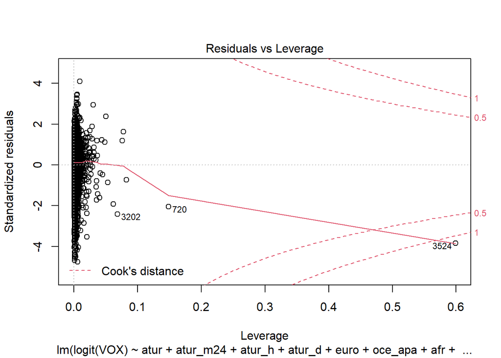

```r
plot(model04,5)
```

###Es pot observar una gran heterocedasticitat amb outliers que provoquen una cua important a l’esquerra. Per tant, intentarem fer el model més fiable traient aquests outliers. Abans utilitzarem el factor d’inflació de varianza per detectar colinealitats.

```r
vif(model04)
```

```
##               atur           atur_m24             atur_h             atur_d
##         403.510894           1.516618          94.367698         150.296126
##               euro            oce_apa                afr                  h
##          75.268657           1.030434           1.237889           1.477987
## Renta_neta_persona                 UE              pob_t             e20_29
##           1.892231          74.375277           1.042703           1.803918
##             e30_39             e40_49             e50_59                M80
##           2.344595           2.542211           1.481927           4.729273
##         Gini_medio
##           1.285293
```

###D’entrada, es pot observar que l’atur, atur d’homes, atur de dones i població europea junt amb UE presenten un registre molt elevat, i per tant, les traurem del model.

```r
model06 <- lm(logit(VOX) ~ atur_m24 + oce_apa + afr + h + Renta_neta_persona + pob_t + e20_29 + e30_39 + e40_49 + e50_59 + M80 + Gini_medio, data=d2)
summary(model06)
```

```
##
## Call:
## lm(formula = logit(VOX) ~ atur_m24 + oce_apa + afr + h + Renta_neta_persona +
##     pob_t + e20_29 + e30_39 + e40_49 + e50_59 + M80 + Gini_medio,
##     data = d2)
##
## Residuals:
##     Min      1Q  Median      3Q     Max
## -3.6227 -0.3940  0.1165  0.4929  3.1285
##
## Coefficients:
##                      Estimate Std. Error t value Pr(>|t|)
## (Intercept)        -6.427e+00  2.612e-01 -24.604  < 2e-16 ***
## atur_m24            1.438e+00  2.238e-01   6.424 1.43e-10 ***
## oce_apa            -1.270e+02  2.389e+01  -5.318 1.08e-07 ***
## afr                -3.120e+00  3.702e-01  -8.428  < 2e-16 ***
## h                   4.929e+00  3.491e-01  14.118  < 2e-16 ***
## Renta_neta_persona -1.620e-04  5.020e-06 -32.274  < 2e-16 ***
## pob_t               9.005e-07  1.817e-07   4.956 7.38e-07 ***
## e20_29              2.856e+00  5.428e-01   5.262 1.47e-07 ***
## e30_39              5.214e+00  5.101e-01  10.222  < 2e-16 ***
## e40_49              5.422e+00  4.672e-01  11.604  < 2e-16 ***
## e50_59              3.345e+00  4.383e-01   7.631 2.68e-14 ***
## M80                 3.522e+00  3.480e-01  10.121  < 2e-16 ***
## Gini_medio          2.727e-02  3.177e-03   8.584  < 2e-16 ***
## ---
## Signif. codes:  0 '***' 0.001 '**' 0.01 '*' 0.05 '.' 0.1 ' ' 1
##
## Residual standard error: 0.7611 on 6309 degrees of freedom
## Multiple R-squared:  0.2344, Adjusted R-squared:  0.2329
## F-statistic: 160.9 on 12 and 6309 DF,  p-value: < 2.2e-16
```

###L’adjust ens baixa una mica, però totes les variables continuen sent significatives.

```r
vif(model06)
```

```
##           atur_m24            oce_apa                afr                  h
##           1.151776           1.027042           1.201430           1.239657
## Renta_neta_persona              pob_t             e20_29             e30_39
##           1.346041           1.035429           1.779052           2.334623
##             e40_49             e50_59                M80         Gini_medio
##           2.530596           1.472063           4.491197           1.098123
```

### En el model 06 no tenim problemes de multicolinealitat.

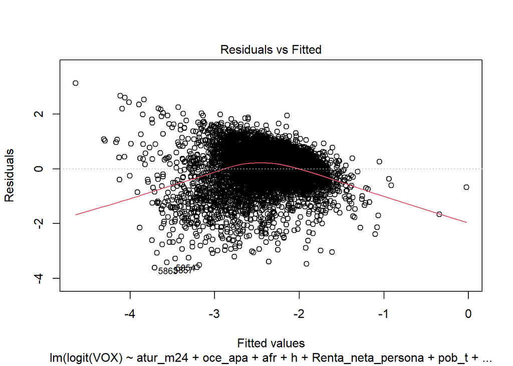

```r
plot(model06,1)
```

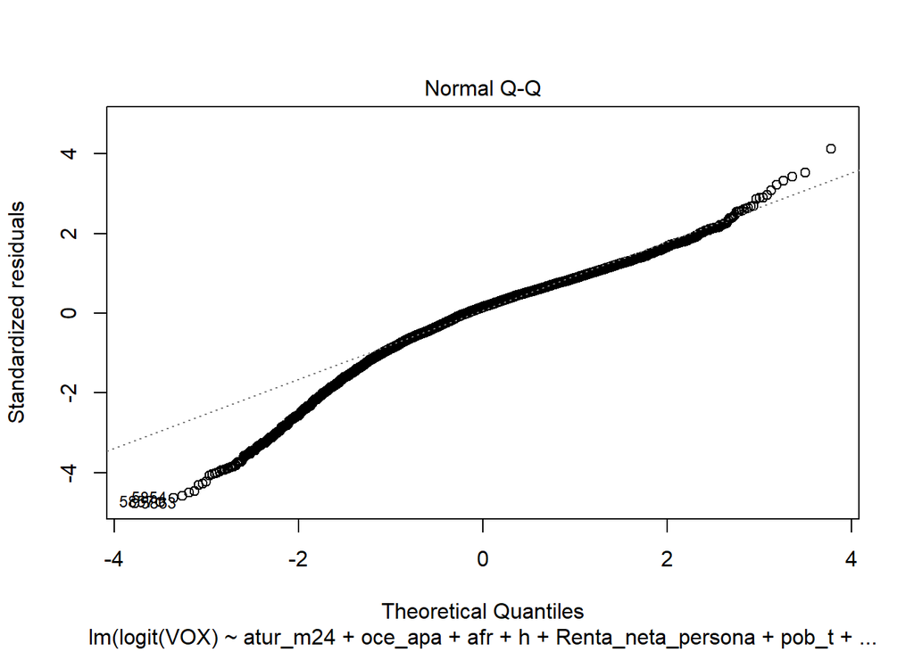

```r
plot(model06,2)
```

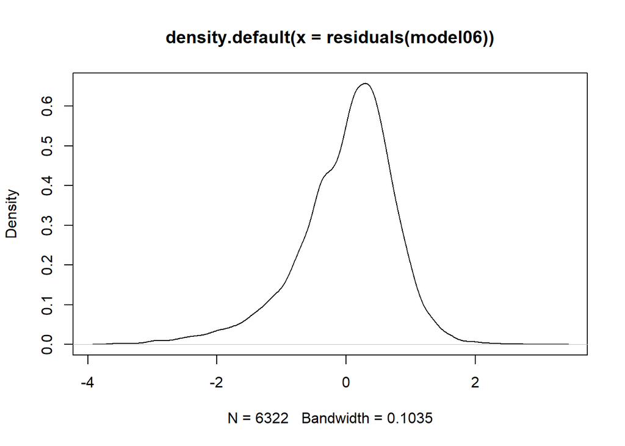

```r
plot(density(residuals(model06)))
```

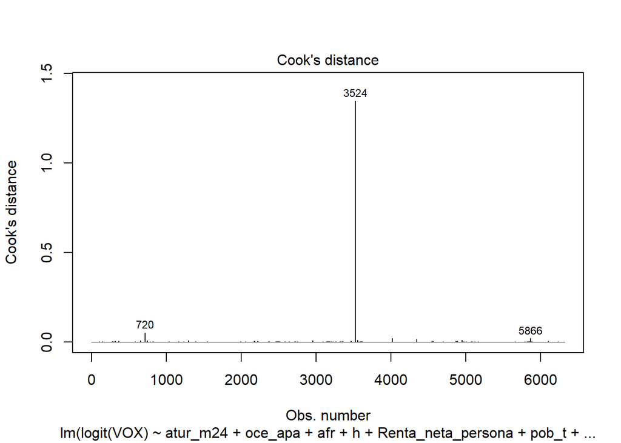

```r
plot(model06,4)
```

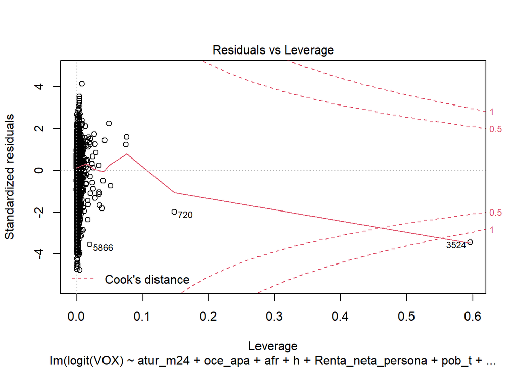

```r
plot(model06,5)
```

###Per contra, els residus continuen tenint el mateix problema. Anem a modelar els diferents outliers.

```r
d4 <- d2
d4=d4[-c(3524,720,5866),]
```

```r
model07 <- lm(logit(VOX) ~ atur_m24 + oce_apa + afr + h + Renta_neta_persona + pob_t + e20_29 + e30_39 + e40_49 + e50_59 + M80 + Gini_medio, data=d4)
summary(model07)
```

```
##
## Call:
## lm(formula = logit(VOX) ~ atur_m24 + oce_apa + afr + h + Renta_neta_persona +
##     pob_t + e20_29 + e30_39 + e40_49 + e50_59 + M80 + Gini_medio,
##     data = d4)
##
## Residuals:
##     Min      1Q  Median      3Q     Max
## -3.6258 -0.3974  0.1157  0.4917  3.0259
##
## Coefficients:
##                      Estimate Std. Error t value Pr(>|t|)
## (Intercept)        -6.528e+00  2.610e-01 -25.010  < 2e-16 ***
## atur_m24            1.407e+00  2.232e-01   6.302 3.13e-10 ***
## oce_apa            -1.139e+02  2.405e+01  -4.738 2.21e-06 ***
## afr                -3.175e+00  3.692e-01  -8.600  < 2e-16 ***
## h                   5.163e+00  3.506e-01  14.727  < 2e-16 ***
## Renta_neta_persona -1.633e-04  5.012e-06 -32.582  < 2e-16 ***
## pob_t               2.589e-06  3.569e-07   7.256 4.47e-13 ***
## e20_29              2.789e+00  5.412e-01   5.153 2.64e-07 ***
## e30_39              5.210e+00  5.085e-01  10.246  < 2e-16 ***
## e40_49              5.416e+00  4.657e-01  11.629  < 2e-16 ***
## e50_59              3.386e+00  4.370e-01   7.748 1.08e-14 ***
## M80                 3.612e+00  3.472e-01  10.403  < 2e-16 ***
## Gini_medio          2.647e-02  3.169e-03   8.352  < 2e-16 ***
## ---
## Signif. codes:  0 '***' 0.001 '**' 0.01 '*' 0.05 '.' 0.1 ' ' 1
##
## Residual standard error: 0.7587 on 6306 degrees of freedom
## Multiple R-squared:  0.2372, Adjusted R-squared:  0.2357
## F-statistic: 163.4 on 12 and 6306 DF,  p-value: < 2.2e-16
```

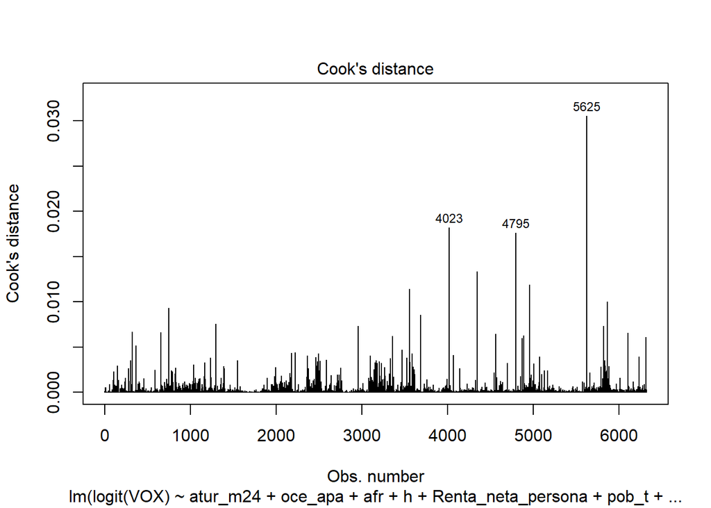

```r
plot(model07,4)
```

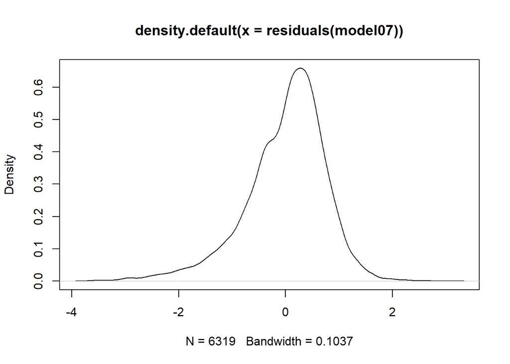

```r
plot(density(residuals(model07)))
```

###Traiem els nous outliers. A partir d’ara ens centrarem en anar traient observacions atípiques del model per tal de reduir la heterocedasticitat.

```r
d4 <- d2
d4=d4[-c(3524,720,5866,4023,4795,5625),]
```

```r
model08 <- lm(logit(VOX) ~ atur_m24 + oce_apa + afr + h + Renta_neta_persona + pob_t + e20_29 + e30_39 + e40_49 + e50_59 + M80 + Gini_medio, data=d4)
summary(model08)
```

```
##
## Call:
## lm(formula = logit(VOX) ~ atur_m24 + oce_apa + afr + h + Renta_neta_persona +
##     pob_t + e20_29 + e30_39 + e40_49 + e50_59 + M80 + Gini_medio,
##     data = d4)
##
## Residuals:
##     Min      1Q  Median      3Q     Max
## -3.5989 -0.3973  0.1147  0.4916  2.9960
##
## Coefficients:
##                      Estimate Std. Error t value Pr(>|t|)
## (Intercept)        -6.540e+00  2.611e-01 -25.053  < 2e-16 ***
## atur_m24            1.406e+00  2.231e-01   6.300 3.18e-10 ***
## oce_apa            -1.252e+02  2.464e+01  -5.082 3.85e-07 ***
## afr                -3.191e+00  3.691e-01  -8.644  < 2e-16 ***
## h                   5.187e+00  3.512e-01  14.769  < 2e-16 ***
## Renta_neta_persona -1.634e-04  5.012e-06 -32.606  < 2e-16 ***
## pob_t               3.037e-06  4.070e-07   7.463 9.59e-14 ***
## e20_29              2.785e+00  5.410e-01   5.147 2.73e-07 ***
## e30_39              5.183e+00  5.083e-01  10.197  < 2e-16 ***
## e40_49              5.425e+00  4.656e-01  11.653  < 2e-16 ***
## e50_59              3.390e+00  4.369e-01   7.760 9.83e-15 ***
## M80                 3.626e+00  3.470e-01  10.449  < 2e-16 ***
## Gini_medio          2.645e-02  3.168e-03   8.350  < 2e-16 ***
## ---
## Signif. codes:  0 '***' 0.001 '**' 0.01 '*' 0.05 '.' 0.1 ' ' 1
##
## Residual standard error: 0.7583 on 6303 degrees of freedom
## Multiple R-squared:  0.2381, Adjusted R-squared:  0.2367
## F-statistic: 164.2 on 12 and 6303 DF,  p-value: < 2.2e-16
```

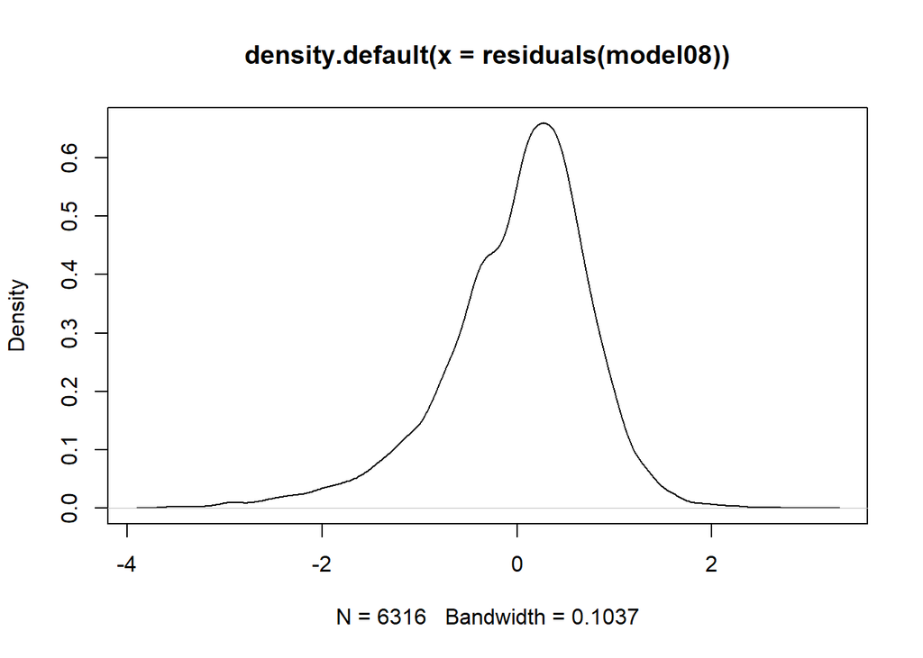

```r
plot(density(residuals(model08)))
```

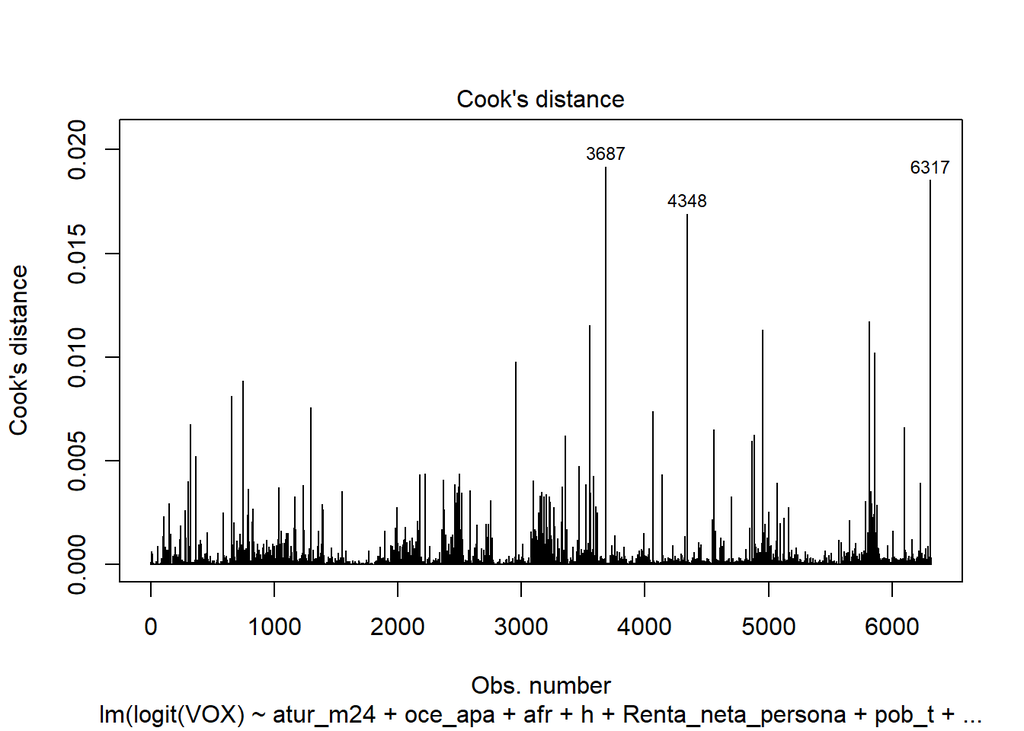

```r
plot(model08,4)
```

```r
d4 <- d2
d4=d4[-c(3524,720,5866,4023,4795,5625,3687,4348,5866),]
```

```r
model09 <- lm(logit(VOX) ~ atur_m24 + oce_apa + afr + h + Renta_neta_persona + pob_t + e20_29 + e30_39 + e40_49 + e50_59 + M80 + Gini_medio, data=d4)
summary(model09)
```

```
##
## Call:
## lm(formula = logit(VOX) ~ atur_m24 + oce_apa + afr + h + Renta_neta_persona +
##     pob_t + e20_29 + e30_39 + e40_49 + e50_59 + M80 + Gini_medio,
##     data = d4)
##
## Residuals:
##     Min      1Q  Median      3Q     Max
## -3.5806 -0.3962  0.1138  0.4913  2.9836
##
## Coefficients:
##                      Estimate Std. Error t value Pr(>|t|)
## (Intercept)        -6.538e+00  2.611e-01 -25.037  < 2e-16 ***
## atur_m24            1.391e+00  2.232e-01   6.233 4.87e-10 ***
## oce_apa            -1.365e+02  2.568e+01  -5.315 1.10e-07 ***
## afr                -3.199e+00  3.691e-01  -8.668  < 2e-16 ***
## h                   5.196e+00  3.515e-01  14.779  < 2e-16 ***
## Renta_neta_persona -1.636e-04  5.013e-06 -32.629  < 2e-16 ***
## pob_t               3.237e-06  4.264e-07   7.590 3.67e-14 ***
## e20_29              2.776e+00  5.409e-01   5.132 2.95e-07 ***
## e30_39              5.164e+00  5.083e-01  10.158  < 2e-16 ***
## e40_49              5.418e+00  4.655e-01  11.640  < 2e-16 ***
## e50_59              3.390e+00  4.368e-01   7.762 9.72e-15 ***
## M80                 3.616e+00  3.471e-01  10.418  < 2e-16 ***
## Gini_medio          2.647e-02  3.168e-03   8.357  < 2e-16 ***
## ---
## Signif. codes:  0 '***' 0.001 '**' 0.01 '*' 0.05 '.' 0.1 ' ' 1
##
## Residual standard error: 0.7581 on 6301 degrees of freedom
## Multiple R-squared:  0.2387, Adjusted R-squared:  0.2372
## F-statistic: 164.6 on 12 and 6301 DF,  p-value: < 2.2e-16
```

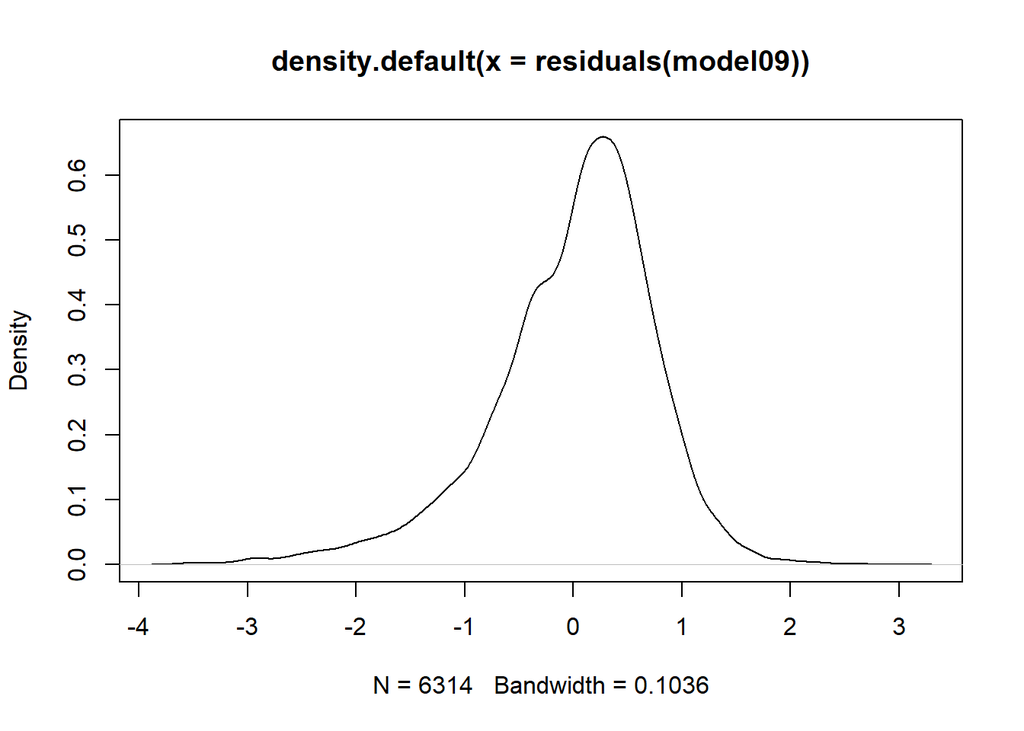

```r
plot(density(residuals(model09)))
```

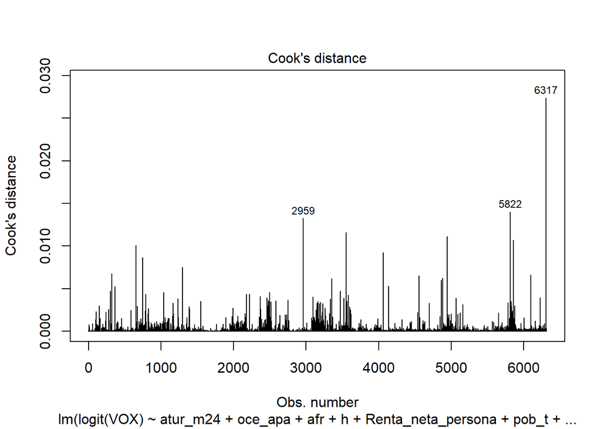

```r
plot(model09,4)
```

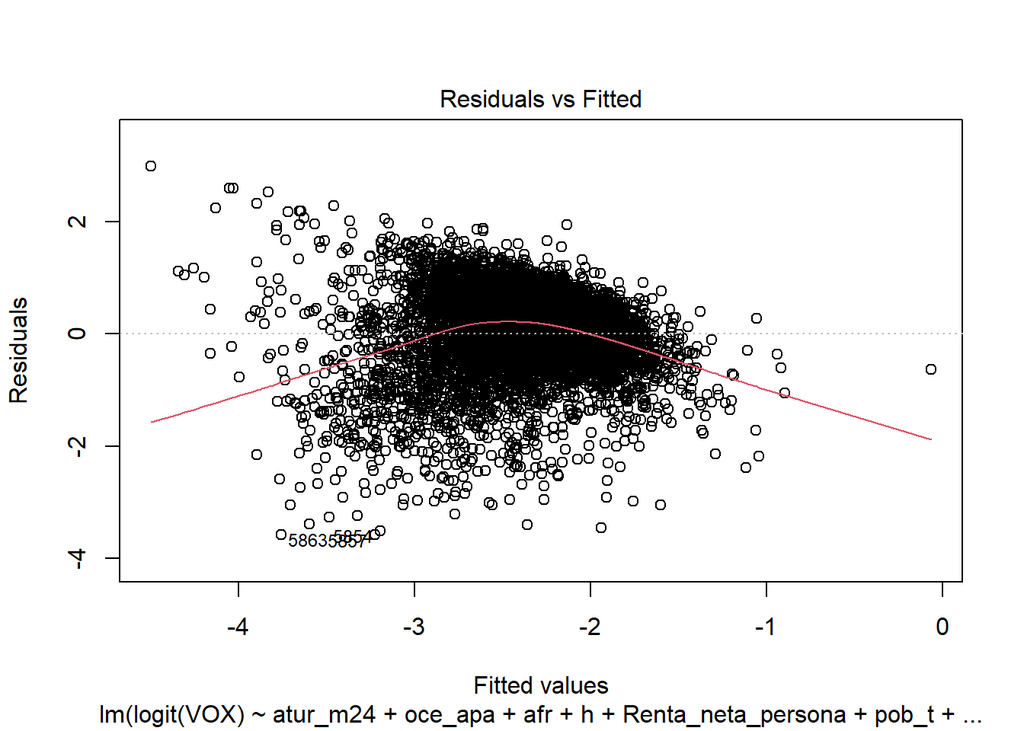

```r
plot(model09,1)
```

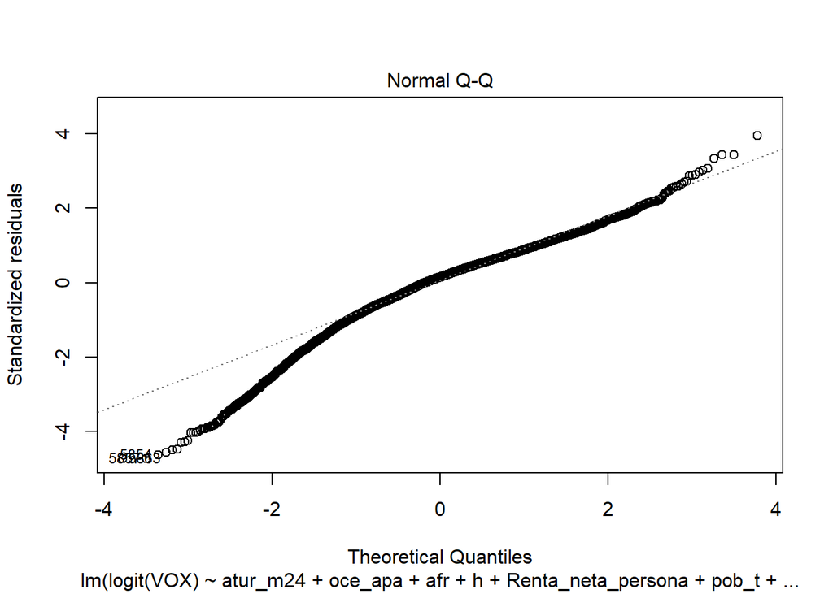

```r
plot(model09,2)
```

###Encara tenim un seriós problema d’heterocedasticitat.

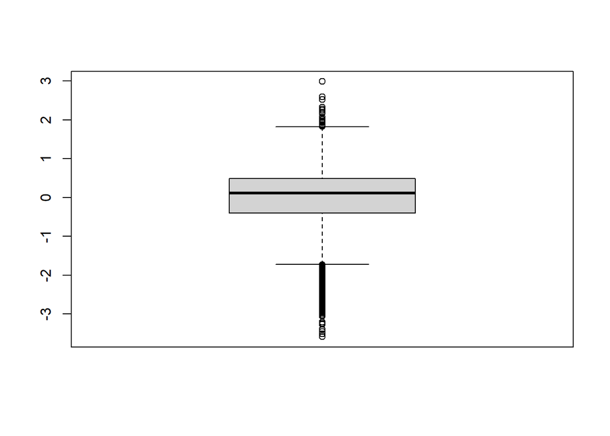

```r
outliers<-boxplot(model09$residuals)
```

```r
outliers$out
```

```
##        56       408       484       588       712       724       736       739
## -2.008674 -1.991315 -1.753062 -1.872503 -1.924539 -2.493088 -2.325423 -2.210058
##       775       797       824       829       831       834       843       936
## -1.950399 -2.454395 -2.126791 -3.041865 -2.320865 -1.829373 -1.883199 -1.952595
##       940       972      1112      1169      1299      1405      1466      1993
## -2.001135 -1.786375  1.960141  2.060881 -1.767335 -1.902761  1.829808 -2.406042
##      1994      2018      2041      2048      2054      2058      2062      2068
## -1.904841 -1.801853 -2.005511 -1.913675 -1.785727 -2.049914 -1.757800 -1.751231
##      2075      2086      2090      2097      2098      2117      2127      2150
## -1.739187 -1.772712 -2.040661 -1.833781 -2.607517 -1.930990 -2.077104 -2.273873
##      2157      2162      2171      2173      2178      2221      2368      2376
## -2.905485 -2.097278 -2.187163 -2.888888 -2.125733 -2.375190  1.850758  1.974584
##      2466      2468      2469      2471      2472      2474      2476      2477
## -3.242317 -2.078863 -2.125439 -2.970011 -2.543138 -2.178562 -1.985998 -3.257647
##      2478      2479      2480      2481      2482      2490      2491      2492
## -2.451143 -1.997680 -2.908626 -2.779123 -2.003776 -2.399816 -2.598719 -1.785837
##      2494      2498      2499      2500      2502      2503      2505      2507
## -3.047256 -3.052718 -1.808629 -2.572192 -1.912672 -1.955119 -2.834604 -2.149841
##      2508      2510      2514      2516      2519      2520      2527      2587
## -1.789872 -1.938583 -1.804950 -3.390390 -1.980192 -2.005120 -2.245584 -3.454850
##      2633      2643      2715      2725      3082      3085      3092      3095
##  2.048705  1.943959  2.190977  1.875057 -2.821544 -2.432554 -2.723154 -1.835894
##      3097      3100      3108      3112      3114      3120      3123      3130
## -2.973498 -2.283750 -2.836698 -3.004227 -2.128112 -1.810026 -2.218147 -1.853189
##      3131      3134      3136      3137      3141      3142      3155      3158
## -1.766479 -2.525580 -1.809401 -2.050728 -2.271170 -2.616400 -2.163678 -1.760667
##      3159      3165      3166      3168      3169      3178      3181      3182
## -2.019022 -1.863040 -2.362914 -2.908840 -1.928267 -2.371520 -2.249808 -2.948216
##      3183      3198      3202      3207      3208      3211      3217      3220
## -1.960345 -2.149198 -2.513372 -2.613707 -2.282529 -2.238062 -2.445156 -3.399175
##      3221      3225      3227      3230      3231      3239      3245      3249
## -1.773332 -1.749313 -2.293923 -2.233312 -2.499134 -2.361738 -1.852810 -2.006036
##      3265      3266      3270      3295      3324      3348      3358      3371
## -2.571606 -2.678151 -2.459933 -1.905538 -2.283493 -2.043198 -3.051789 -1.849752
##      3471      3525      3556      3565      3586      3603      3610      3615
##  2.591625  2.323565  2.983603  2.170155  2.590151  2.278013  2.008779  2.183964
##      3620      3797      4563      4702      4873      4888      4896      4907
##  1.921871 -1.730128 -2.182691  2.238095 -2.373923 -2.976121 -1.874967 -1.800732
##      4918      4927      4934      4949      4960      4963      4966      4968
## -2.361077 -1.928767 -2.038323 -2.161212 -1.942828 -2.231519 -1.936873 -1.949143
##      4969      4971      4977      4978      4979      4983      5005      5012
## -2.113689 -2.108801 -2.950868 -2.323409 -1.979862 -2.352097 -1.812178 -1.803637
##      5015      5028      5035      5661      5713      5793      5810      5811
## -2.056929 -2.128595 -1.762735  1.858411  1.962768  1.935536 -2.542707 -2.288027
##      5812      5814      5819      5820      5823      5824      5826      5827
## -2.668941 -1.821512 -2.848580 -2.416910 -2.669647 -1.976802 -2.660365 -2.437122
##      5828      5830      5832      5834      5837      5838      5846      5847
## -2.010941 -1.749531 -2.728980 -2.127275 -2.526544 -2.586215 -1.893564 -2.258359
##      5848      5849      5852      5853      5854      5855      5856      5857
## -2.377197 -1.904770 -2.047843 -2.009532 -3.508915 -2.094426 -2.934171 -3.580632
##      5860      5861      5862      5863      5867      5873      5881      5884
## -2.447896 -2.204589 -1.794497 -3.574204 -2.503981 -3.209515 -2.707160 -2.347612
##      5886      5888      5895      5896      6109      6235      6277
## -1.906808 -1.937545 -1.739724 -1.866960 -2.142059  2.520019 -1.801886
```

```r
d4 <- d2
d4=d4[-c(3524,720,5866,4023,4795,5625,3687,4348,5866,56,408,484,588,712,724,736,739,775, 797,824,829,831,834,843,936,940,972,1112,1169,1299,1405,1466,1993,1994,2018,2041,2048,2054,2058,2062,2068,2075,2086,2090,2097,2098,2117,2127,2150,2157,2162,2171,2173,2178,2221,2368,2376,2466,2468,2469,2471,2472,2474,2476,2477,2478,2479,2480,2481,2482,2490,2491,2492,2494,2498,2499,2500,2502,2503,2505,2507,2508,2510,2514,2516,2519,2520,2527,2587,2633,2643,2715,2725,3082,3085,3092,3095,3097,3100,3108,3112,3114,3120,3123,3130,3131,3134,3136,3137,3141,3142,3155,3158,3159,3165,3166,3168,3169,3178,3181,3182,3183,3198,3202,3207,3208,3211,3217,3220,3221,3225,3227,3230,3231,3239,3245,3249,3265,3266,3270,3295,3324,3348,3358,3371,3471,3525,3556,3565,3586,3603,3610,3615,3620,3797,4563,4702,4873,4888,4896,4907,4918,4927,4934,4949,4960,4963,4966,4968,4969,4971,4977,4978,4979,4983,5005,5012,5015,5028,5035,5661,5713,5793,5810,5811,5812,5814,5819,5820,5823,5824,5826,5827,5828,5830,5832,5834,5837,5838,5846,5847,5848,5849,5852,5853,5854,5855,5856,5857,5860,5861,5862,5863,5867,5873,5881,5884,5886,5888,5895,5896,6109,6235,6277),]
```

```r
model10 <- lm(logit(VOX) ~ atur_m24 + oce_apa + afr + h + Renta_neta_persona + pob_t + e20_29 + e30_39 + e40_49 + e50_59 + M80 + Gini_medio, data=d4)
summary(model10)
```

```
##
## Call:
## lm(formula = logit(VOX) ~ atur_m24 + oce_apa + afr + h + Renta_neta_persona +
##     pob_t + e20_29 + e30_39 + e40_49 + e50_59 + M80 + Gini_medio,
##     data = d4)
##
## Residuals:
##      Min       1Q   Median       3Q      Max
## -1.91417 -0.39657  0.08589  0.43753  1.68182
##
## Coefficients:
##                      Estimate Std. Error t value Pr(>|t|)
## (Intercept)        -6.712e+00  2.235e-01 -30.030  < 2e-16 ***
## atur_m24            1.277e+00  1.900e-01   6.722 1.95e-11 ***
## oce_apa            -1.361e+02  2.177e+01  -6.254 4.27e-10 ***
## afr                -2.726e+00  3.130e-01  -8.708  < 2e-16 ***
## h                   5.566e+00  3.004e-01  18.529  < 2e-16 ***
## Renta_neta_persona -1.416e-04  4.422e-06 -32.033  < 2e-16 ***
## pob_t               2.215e-06  3.581e-07   6.187 6.54e-10 ***
## e20_29              2.039e+00  4.617e-01   4.416 1.02e-05 ***
## e30_39              5.090e+00  4.332e-01  11.751  < 2e-16 ***
## e40_49              4.938e+00  3.973e-01  12.428  < 2e-16 ***
## e50_59              3.568e+00  3.720e-01   9.593  < 2e-16 ***
## M80                 2.846e+00  2.957e-01   9.626  < 2e-16 ***
## Gini_medio          2.643e-02  2.728e-03   9.686  < 2e-16 ***
## ---
## Signif. codes:  0 '***' 0.001 '**' 0.01 '*' 0.05 '.' 0.1 ' ' 1
##
## Residual standard error: 0.6336 on 6086 degrees of freedom
## Multiple R-squared:  0.2507, Adjusted R-squared:  0.2492
## F-statistic: 169.7 on 12 and 6086 DF,  p-value: < 2.2e-16
```

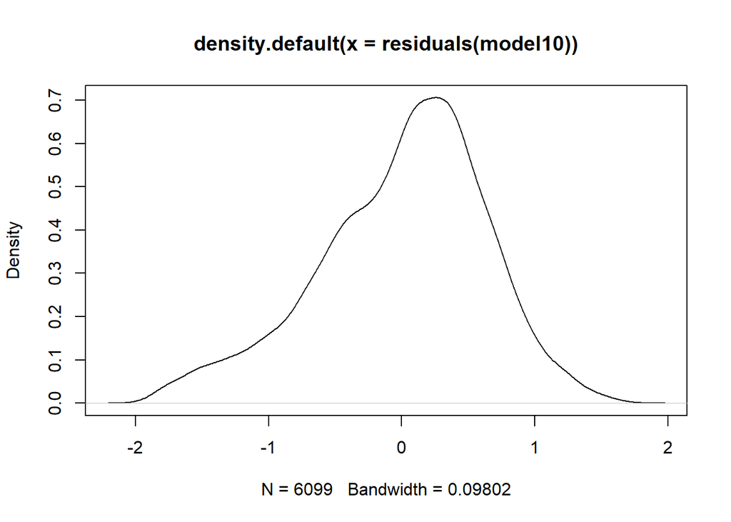

```r
plot(density(residuals(model10)))
```

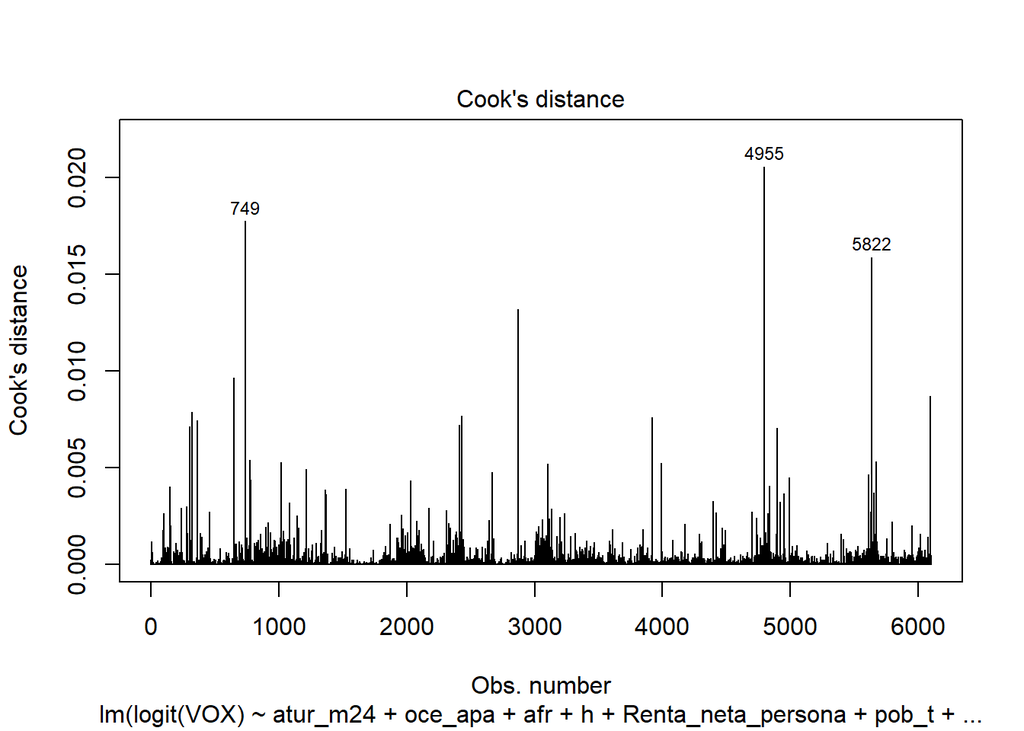

```r
plot(model10,4)
```

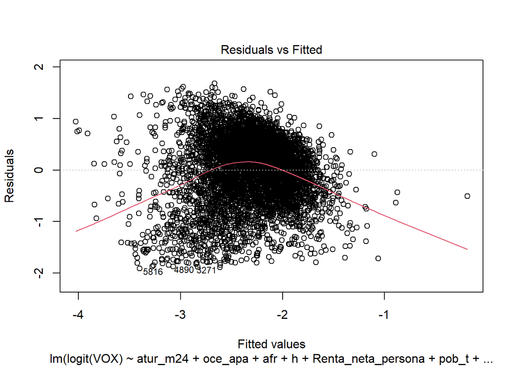

```r
plot(model10,1)
```

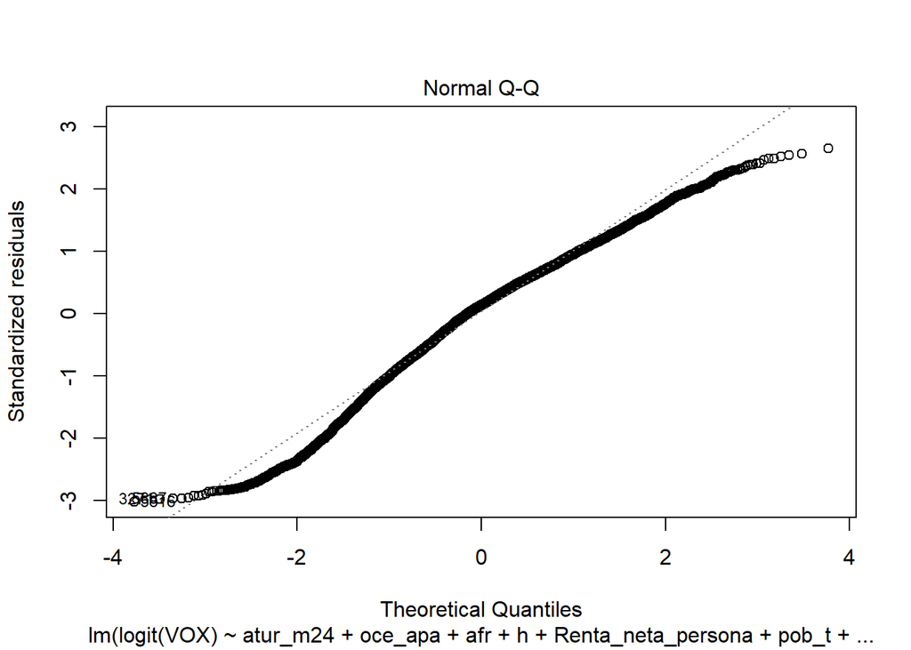

```r
plot(model10,2)
```

```r
vif(model10)
```

```
##           atur_m24            oce_apa                afr                  h
##           1.148985           1.030979           1.203478           1.264662
## Renta_neta_persona              pob_t             e20_29             e30_39
##           1.351582           1.101557           1.800902           2.363068
##             e40_49             e50_59                M80         Gini_medio
##           2.567086           1.474970           4.588795           1.100276
```

```r
library(tseries)
jarque.bera.test(model10$residuals)
```

```
##
##  Jarque Bera Test
##
## data:  model10$residuals
## X-squared = 242.94, df = 2, p-value < 2.2e-16
```

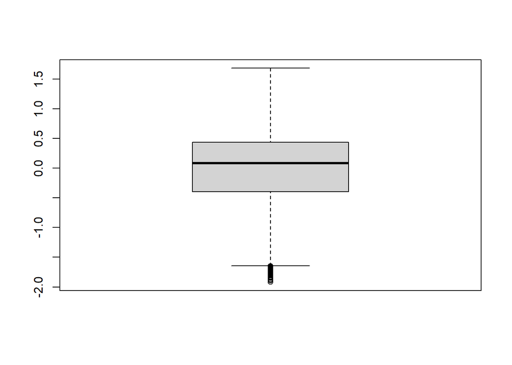

```r
outliers<-boxplot(model10$residuals)
```

```r
outliers$out
```

```
##       391       547       748       751       760       783       836       852
## -1.793784 -1.665990 -1.648191 -1.701178 -1.793513 -1.847486 -1.781671 -1.805348
##       862       957       987      1999      2004      2006      2038      2061
## -1.785511 -1.803915 -1.744140 -1.780542 -1.751379 -1.728622 -1.876181 -1.788600
##      2064      2081      2107      2119      2123      2124      2126      2143
## -1.699379 -1.689232 -1.723650 -1.763017 -1.717237 -1.657222 -1.788643 -1.760984
##      2149      2174      2177      2470      2475      2486      2487      2497
## -1.773615 -1.810185 -1.724114 -1.706220 -1.850554 -1.778753 -1.807178 -1.697128
##      2511      2512      3099      3101      3106      3118      3132      3160
## -1.654146 -1.655856 -1.733247 -1.797350 -1.800336 -1.755970 -1.712189 -1.684935
##      3161      3164      3200      3228      3256      3271      3650      4438
## -1.844109 -1.773038 -1.673918 -1.664620 -1.832185 -1.887433 -1.720376 -1.703121
##      4547      4575      4890      4917      4941      4974      5808      5816
## -1.719699 -1.793241 -1.877679 -1.668225 -1.739550 -1.773276 -1.775770 -1.914166
##      5833      5843      5877      5882      5887      5890      5894      5899
## -1.811402 -1.741263 -1.676624 -1.663176 -1.873711 -1.686701 -1.736713 -1.765554
```

```r
d4 <- d2
d4=d4[-c(3524,720,5866,4023,4795,5625,3687,4348,5866,56,408,484,588,712,724,736,739,775, 797,824,829,831,834,843,936,940,972,1112,1169,1299,1405,1466,1993,1994,2018,2041,2048,2054,2058,2062,2068,2075,2086,2090,2097,2098,2117,2127,2150,2157,2162,2171,2173,2178,2221,2368,2376,2466,2468,2469,2471,2472,2474,2476,2477,2478,2479,2480,2481,2482,2490,2491,2492,2494,2498,2499,2500,2502,2503,2505,2507,2508,2510,2514,2516,2519,2520,2527,2587,2633,2643,2715,2725,3082,3085,3092,3095,3097,3100,3108,3112,3114,3120,3123,3130,3131,3134,3136,3137,3141,3142,3155,3158,3159,3165,3166,3168,3169,3178,3181,3182,3183,3198,3202,3207,3208,3211,3217,3220,3221,3225,3227,3230,3231,3239,3245,3249,3265,3266,3270,3295,3324,3348,3358,3371,3471,3525,3556,3565,3586,3603,3610,3615,3620,3797,4563,4702,4873,4888,4896,4907,4918,4927,4934,4949,4960,4963,4966,4968,4969,4971,4977,4978,4979,4983,5005,5012,5015,5028,5035,5661,5713,5793,5810,5811,5812,5814,5819,5820,5823,5824,5826,5827,5828,5830,5832,5834,5837,5838,5846,5847,5848,5849,5852,5853,5854,5855,5856,5857,5860,5861,5862,5863,5867,5873,5881,5884,5886,5888,5895,5896,6109,6235,6277, 143,161,323,367,440,1027,1842,1885,1896,2365,2373,2391,2412,2416,2434,2462,3511,3515,3606,3654,3760,3984,4019,4169,4304,4326,4619,4627,5217,5573,5615,5790,6090,6274 ),]
```

```r
model11 <- lm(logit(VOX) ~ atur_m24 + oce_apa + afr + h + Renta_neta_persona + pob_t + e20_29 + e30_39 + e40_49 + e50_59 + M80 + Gini_medio, data=d4)
summary(model11)
```

```
##
## Call:
## lm(formula = logit(VOX) ~ atur_m24 + oce_apa + afr + h + Renta_neta_persona +
##     pob_t + e20_29 + e30_39 + e40_49 + e50_59 + M80 + Gini_medio,
##     data = d4)
##
## Residuals:
##     Min      1Q  Median      3Q     Max
## -1.9041 -0.3940  0.0891  0.4371  1.5896
##
## Coefficients:
##                      Estimate Std. Error t value Pr(>|t|)
## (Intercept)        -6.671e+00  2.226e-01 -29.967  < 2e-16 ***
## atur_m24            1.366e+00  1.886e-01   7.239 5.10e-13 ***
## oce_apa            -1.369e+02  2.165e+01  -6.324 2.73e-10 ***
## afr                -2.737e+00  3.120e-01  -8.773  < 2e-16 ***
## h                   5.519e+00  3.008e-01  18.348  < 2e-16 ***
## Renta_neta_persona -1.419e-04  4.388e-06 -32.339  < 2e-16 ***
## pob_t               2.264e-06  3.548e-07   6.381 1.88e-10 ***
## e20_29              1.911e+00  4.596e-01   4.157 3.26e-05 ***
## e30_39              5.077e+00  4.313e-01  11.771  < 2e-16 ***
## e40_49              4.989e+00  3.964e-01  12.585  < 2e-16 ***
## e50_59              3.612e+00  3.708e-01   9.742  < 2e-16 ***
## M80                 2.821e+00  2.943e-01   9.586  < 2e-16 ***
## Gini_medio          2.556e-02  2.714e-03   9.416  < 2e-16 ***
## ---
## Signif. codes:  0 '***' 0.001 '**' 0.01 '*' 0.05 '.' 0.1 ' ' 1
##
## Residual standard error: 0.6275 on 6052 degrees of freedom
## Multiple R-squared:  0.2556, Adjusted R-squared:  0.2541
## F-statistic: 173.2 on 12 and 6052 DF,  p-value: < 2.2e-16
```

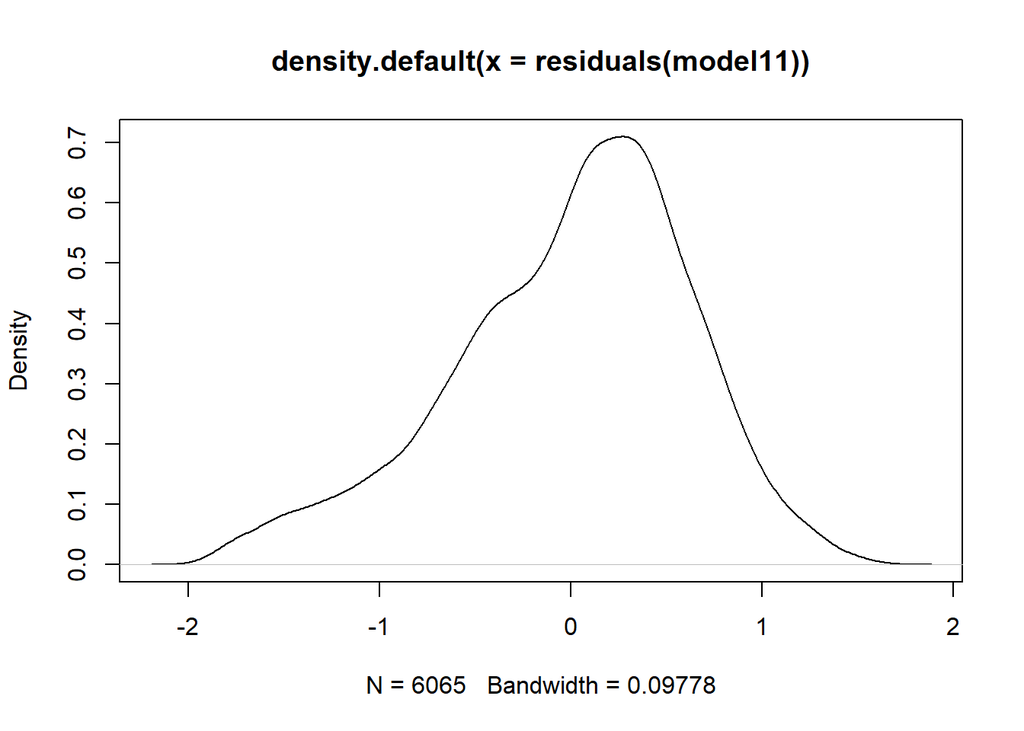

```r
plot(density(residuals(model11)))
```

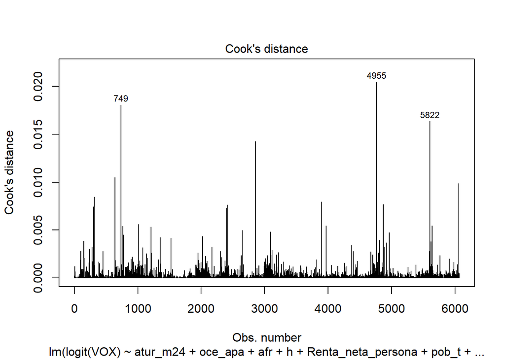

```r
plot(model11,4)
```

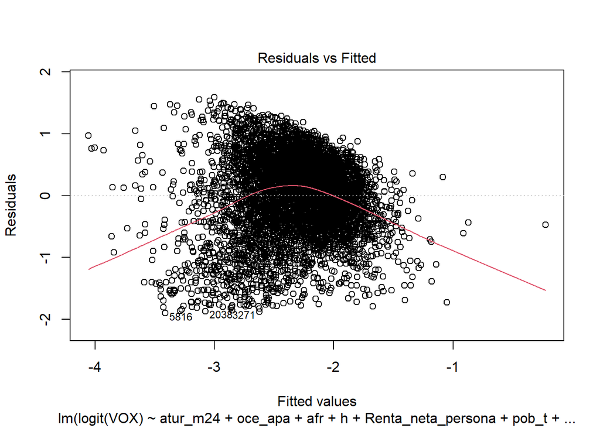

```r
plot(model11,1)
```

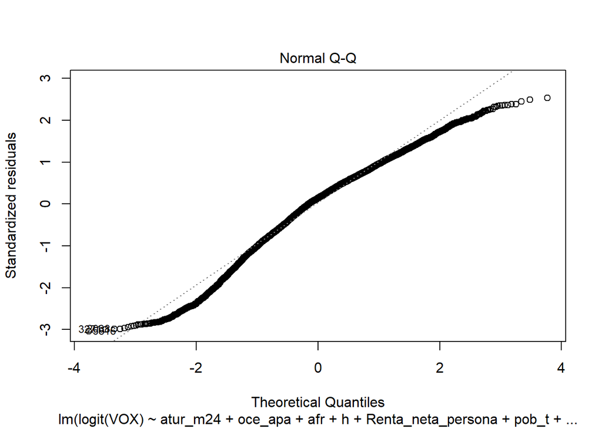

```r
plot(model11,2)
```

```r
vif(model11)
```

```
##           atur_m24            oce_apa                afr                  h
##           1.149290           1.031964           1.202144           1.272176
## Renta_neta_persona              pob_t             e20_29             e30_39
##           1.350956           1.101913           1.803464           2.373505
##             e40_49             e50_59                M80         Gini_medio
##           2.582591           1.484101           4.615269           1.100474
```

```r
library(tseries)
jarque.bera.test(model11$residuals)
```

```
##
##  Jarque Bera Test
##
## data:  model11$residuals
## X-squared = 274.32, df = 2, p-value < 2.2e-16
```

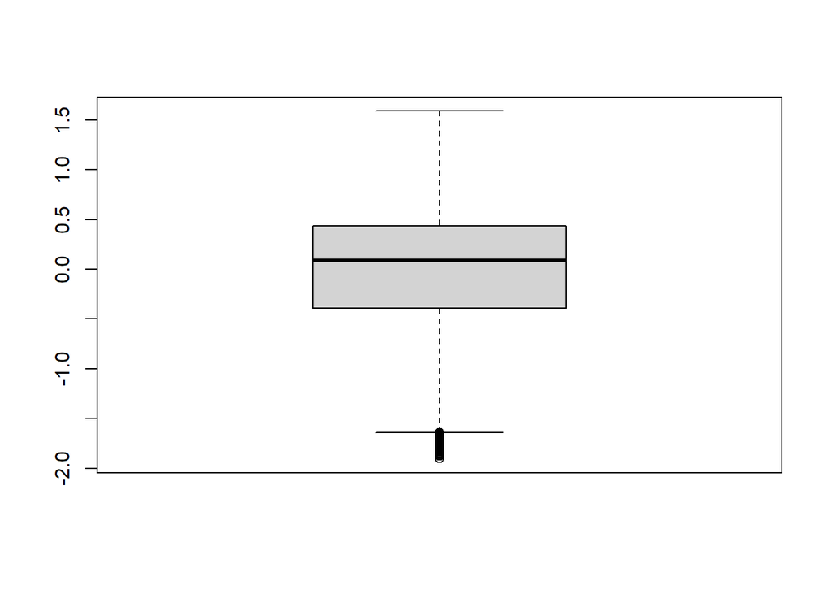

```r
outliers<-boxplot(model11$residuals)
```

```r
outliers$out
```

```
##       391       547       751       760       783       836       852       862
## -1.794205 -1.660574 -1.685568 -1.787892 -1.817358 -1.782791 -1.798113 -1.775977
##       957       987      1999      2004      2006      2038      2061      2064
## -1.790390 -1.731014 -1.767741 -1.741018 -1.720373 -1.872487 -1.767222 -1.694211
##      2081      2107      2119      2123      2124      2126      2143      2149
## -1.682188 -1.715098 -1.750856 -1.707894 -1.648751 -1.777081 -1.749668 -1.766617
##      2174      2177      2470      2475      2486      2487      2497      2511
## -1.803458 -1.710869 -1.701869 -1.841812 -1.772076 -1.806009 -1.690922 -1.650619
##      2512      3099      3101      3106      3118      3132      3160      3161
## -1.649857 -1.722869 -1.777989 -1.788214 -1.740282 -1.703465 -1.669510 -1.829637
##      3164      3200      3228      3256      3271      3650      4438      4547
## -1.762632 -1.659127 -1.655658 -1.819213 -1.878348 -1.720974 -1.690106 -1.728508
##      4575      4890      4917      4941      4974      5807      5808      5816
## -1.794949 -1.859574 -1.653919 -1.724120 -1.755780 -1.643850 -1.770750 -1.904135
##      5833      5843      5877      5882      5887      5890      5894      5899
## -1.802489 -1.733374 -1.672092 -1.658167 -1.865863 -1.683488 -1.727684 -1.761616
```

```r
d4 <- d2
d4=d4[-c(3524,720,5866,4023,4795,5625,3687,4348,5866,56,408,484,588,712,724,736,739,775, 797,824,829,831,834,843,936,940,972,1112,1169,1299,1405,1466,1993,1994,2018,2041,2048,2054,2058,2062,2068,2075,2086,2090,2097,2098,2117,2127,2150,2157,2162,2171,2173,2178,2221,2368,2376,2466,2468,2469,2471,2472,2474,2476,2477,2478,2479,2480,2481,2482,2490,2491,2492,2494,2498,2499,2500,2502,2503,2505,2507,2508,2510,2514,2516,2519,2520,2527,2587,2633,2643,2715,2725,3082,3085,3092,3095,3097,3100,3108,3112,3114,3120,3123,3130,3131,3134,3136,3137,3141,3142,3155,3158,3159,3165,3166,3168,3169,3178,3181,3182,3183,3198,3202,3207,3208,3211,3217,3220,3221,3225,3227,3230,3231,3239,3245,3249,3265,3266,3270,3295,3324,3348,3358,3371,3471,3525,3556,3565,3586,3603,3610,3615,3620,3797,4563,4702,4873,4888,4896,4907,4918,4927,4934,4949,4960,4963,4966,4968,4969,4971,4977,4978,4979,4983,5005,5012,5015,5028,5035,5661,5713,5793,5810,5811,5812,5814,5819,5820,5823,5824,5826,5827,5828,5830,5832,5834,5837,5838,5846,5847,5848,5849,5852,5853,5854,5855,5856,5857,5860,5861,5862,5863,5867,5873,5881,5884,5886,5888,5895,5896,6109,6235,6277, 143,161,323,367,440,1027,1842,1885,1896,2365,2373,2391,2412,2416,2434,2462,3511,3515,3606,3654,3760,3984,4019,4169,4304,4326,4619,4627,5217,5573,5615,5790,6090,6274,391,547,751,760,783,836,852,862,957,987,1999,2004,2006,2038,2061,2064,2081,2107,2119,2123,2124,2126,2143,2149,2174,2177,2470,2475,2486,2487,2497,2511,2512,3099,3101,3106,3118,3132,3160,3161,3164,3200,3228,256,3271,3650,4438,4547,4575,4890,4917,4941,4974,5807,5808,5816,5833,5843,5877,5882,5887,5890,5894,5899,5822,4955,749,2495,6317,2465),]
```

```r
model12 <- lm(logit(VOX) ~ atur_m24 + oce_apa + afr + h + Renta_neta_persona + pob_t + e20_29 + e30_39 + e40_49 + e50_59 + M80 + Gini_medio, data=d4)
summary(model12)
```

```
##
## Call:
## lm(formula = logit(VOX) ~ atur_m24 + oce_apa + afr + h + Renta_neta_persona +
##     pob_t + e20_29 + e30_39 + e40_49 + e50_59 + M80 + Gini_medio,
##     data = d4)
##
## Residuals:
##      Min       1Q   Median       3Q      Max
## -1.86599 -0.38400  0.08229  0.42237  1.52436
##
## Coefficients:
##                      Estimate Std. Error t value Pr(>|t|)
## (Intercept)        -6.628e+00  2.152e-01 -30.799  < 2e-16 ***
## atur_m24            1.351e+00  1.819e-01   7.427 1.27e-13 ***
## oce_apa            -1.003e+02  2.251e+01  -4.454 8.60e-06 ***
## afr                -2.645e+00  3.018e-01  -8.763  < 2e-16 ***
## h                   5.485e+00  2.910e-01  18.848  < 2e-16 ***
## Renta_neta_persona -1.313e-04  4.282e-06 -30.655  < 2e-16 ***
## pob_t               2.241e-06  3.750e-07   5.975 2.43e-09 ***
## e20_29              1.754e+00  4.442e-01   3.949 7.95e-05 ***
## e30_39              4.956e+00  4.164e-01  11.902  < 2e-16 ***
## e40_49              4.706e+00  3.825e-01  12.304  < 2e-16 ***
## e50_59              3.404e+00  3.577e-01   9.517  < 2e-16 ***
## M80                 2.533e+00  2.838e-01   8.924  < 2e-16 ***
## Gini_medio          2.565e-02  2.630e-03   9.755  < 2e-16 ***
## ---
## Signif. codes:  0 '***' 0.001 '**' 0.01 '*' 0.05 '.' 0.1 ' ' 1
##
## Residual standard error: 0.6029 on 5982 degrees of freedom
## Multiple R-squared:  0.2432, Adjusted R-squared:  0.2417
## F-statistic: 160.2 on 12 and 5982 DF,  p-value: < 2.2e-16
```

```r
library(tseries)
jarque.bera.test(model12$residuals)
```

```
##
##  Jarque Bera Test
##
## data:  model12$residuals
## X-squared = 233.7, df = 2, p-value < 2.2e-16
```

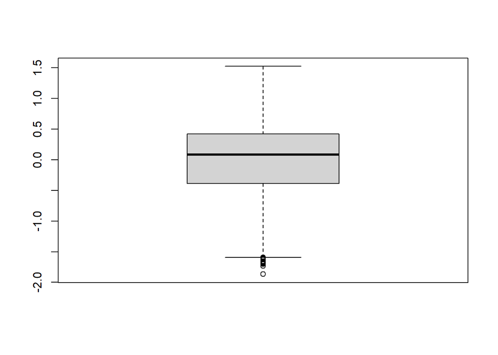

```r
outliers<-boxplot(model12$residuals)
```

```r
outliers$out
```

```
##       212       747       748       777       779       841       914       929
## -1.620756 -1.606460 -1.686469 -1.612480 -1.604714 -1.627782 -1.661571 -1.673358
##       966      2005      2014      2017      2036      2040      2085      2095
## -1.610096 -1.609632 -1.653674 -1.631402 -1.594501 -1.616163 -1.677199 -1.674270
##      2467      2483      2488      2493      2517      2522      2523      2526
## -1.684343 -1.700295 -1.680323 -1.663433 -1.729587 -1.625714 -1.652933 -1.661954
##      3079      3117      3128      3146      3147      3241      3256      3369
## -1.613031 -1.627177 -1.621191 -1.618432 -1.593670 -1.623539 -1.865988 -1.604954
##      4965      5027      5825      5865      5878      5892      5898
## -1.601552 -1.631624 -1.652396 -1.690226 -1.615640 -1.651736 -1.595284
```

```r
d4 <- d2
d4=d4[-c(3524,720,5866,4023,4795,5625,3687,4348,5866,56,408,484,588,712,724,736,739,775, 797,824,829,831,834,843,936,940,972,1112,1169,1299,1405,1466,1993,1994,2018,2041,2048,2054,2058,2062,2068,2075,2086,2090,2097,2098,2117,2127,2150,2157,2162,2171,2173,2178,2221,2368,2376,2466,2468,2469,2471,2472,2474,2476,2477,2478,2479,2480,2481,2482,2490,2491,2492,2494,2498,2499,2500,2502,2503,2505,2507,2508,2510,2514,2516,2519,2520,2527,2587,2633,2643,2715,2725,3082,3085,3092,3095,3097,3100,3108,3112,3114,3120,3123,3130,3131,3134,3136,3137,3141,3142,3155,3158,3159,3165,3166,3168,3169,3178,3181,3182,3183,3198,3202,3207,3208,3211,3217,3220,3221,3225,3227,3230,3231,3239,3245,3249,3265,3266,3270,3295,3324,3348,3358,3371,3471,3525,3556,3565,3586,3603,3610,3615,3620,3797,4563,4702,4873,4888,4896,4907,4918,4927,4934,4949,4960,4963,4966,4968,4969,4971,4977,4978,4979,4983,5005,5012,5015,5028,5035,5661,5713,5793,5810,5811,5812,5814,5819,5820,5823,5824,5826,5827,5828,5830,5832,5834,5837,5838,5846,5847,5848,5849,5852,5853,5854,5855,5856,5857,5860,5861,5862,5863,5867,5873,5881,5884,5886,5888,5895,5896,6109,6235,6277, 143,161,323,367,440,1027,1842,1885,1896,2365,2373,2391,2412,2416,2434,2462,3511,3515,3606,3654,3760,3984,4019,4169,4304,4326,4619,4627,5217,5573,5615,5790,6090,6274,391,547,751,760,783,836,852,862,957,987,1999,2004,2006,2038,2061,2064,2081,2107,2119,2123,2124,2126,2143,2149,2174,2177,2470,2475,2486,2487,2497,2511,2512,3099,3101,3106,3118,3132,3160,3161,3164,3200,3228,256,3271,3650,4438,4547,4575,4890,4917,4941,4974,5807,5808,5816,5833,5843,5877,5882,5887,5890,5894,5899,5822,4955,749,212  ,747,748,777,779,841,914,929,966,2005,2014,2017,2040,2085,2095,2465,2467,2483,2488,2493,2517,2522,2523,2526,3079,3117,3128,3146,3147,3241,3256,3369,4932,4965,5027,5825,5865,5878,5892),]
```

```r
model13 <- lm(logit(VOX) ~ atur_m24 + oce_apa + afr + h + Renta_neta_persona + pob_t + e20_29 + e30_39 + e40_49 + e50_59 + M80 + Gini_medio, data=d4)
summary(model13)
```

```
##
## Call:
## lm(formula = logit(VOX) ~ atur_m24 + oce_apa + afr + h + Renta_neta_persona +
##     pob_t + e20_29 + e30_39 + e40_49 + e50_59 + M80 + Gini_medio,
##     data = d4)
##
## Residuals:
##      Min       1Q   Median       3Q      Max
## -1.64146 -0.37692  0.07804  0.41427  1.46822
##
## Coefficients:
##                      Estimate Std. Error t value Pr(>|t|)
## (Intercept)        -6.490e+00  2.112e-01 -30.733  < 2e-16 ***
## atur_m24            1.321e+00  1.782e-01   7.417 1.36e-13 ***
## oce_apa            -1.009e+02  2.163e+01  -4.664 3.17e-06 ***
## afr                -2.685e+00  2.956e-01  -9.080  < 2e-16 ***
## h                   5.349e+00  2.854e-01  18.745  < 2e-16 ***
## Renta_neta_persona -1.237e-04  4.229e-06 -29.255  < 2e-16 ***
## pob_t               1.968e-06  3.400e-07   5.790 7.41e-09 ***
## e20_29              1.589e+00  4.355e-01   3.649 0.000265 ***
## e30_39              4.874e+00  4.086e-01  11.928  < 2e-16 ***
## e40_49              4.436e+00  3.752e-01  11.823  < 2e-16 ***
## e50_59              3.116e+00  3.513e-01   8.870  < 2e-16 ***
## M80                 2.325e+00  2.783e-01   8.352  < 2e-16 ***
## Gini_medio          2.542e-02  2.581e-03   9.849  < 2e-16 ***
## ---
## Signif. codes:  0 '***' 0.001 '**' 0.01 '*' 0.05 '.' 0.1 ' ' 1
##
## Residual standard error: 0.59 on 5946 degrees of freedom
## Multiple R-squared:  0.232,  Adjusted R-squared:  0.2305
## F-statistic: 149.7 on 12 and 5946 DF,  p-value: < 2.2e-16
```